# Determinants of Economic Growth

Johann Power

12/08/2021

# Introduction

The determinants of economic growth have long been debated in economics and are important to understand in helping improve people’s standards of living across the globe. As Lucas stated: “How did the world economy of today, with its vast differences in income levels and growth rates, emerge from the world of two centuries ago, in which the richest and the poorest societies had income differing by perhaps a factor of two, and in which no society had ever enjoyed sustained growth in living standards?” (Lucas, 2000). The Clark-Fisher three-sector model describes how economies change with their level of development. Least developed countries focus on primary sector activities while more developed countries employ more people in tertiary and quaternary services. These sectoral shifts may explain why different economic growth models better suit different countries based on their level of economic development. For instance, the Malthusian model which described output as a function of technology, land and population based on Malthus (Malthus, 1798) explains well pre-industrial growth. Whereas the original Solow-Swan (Solow, 1956) neoclassical growth model incorporated the role of physical capital and fits the growth patterns observed in industrializing countries like that which occurred in the ‘Asian Tiger’ economies during 1960s but fails to explain why productivity was lower in poorer countries and the slow movement of capital from developed to developing nations. This led to growth models which also incorporated the role of human capital (Romer et al., 1992) and social infrastructure (Hall and Jones, 1999) which better explained growth in higher income countries who had higher levels of human capital and social infrastructure. Therefore, with economic development, the main determinants of long run economic growth tend to change. Without, as of yet, a universal economic growth model with widespread consensus it makes more sense to look at the determinants of economic growth for groups of countries with similar levels of economic development as their economies are, on average, structurally more similar. This paper assigns a country’s level of development into one of four categories based on their average ranking in the Economic Complexity Index (ECI) during the dataset period: most developed countries, developed countries, less developed countries and least developed countries. Fixed effects multiple linear regression analysis is then applied to each group of countries to quantify the associated impact of economic growth determinants on output in structurally similar economies. This will also allow us to observe the relative importance of different economic growth factors as countries develop. This is a fundamentally empirically led study and as such the results of this paper should not be interpreted causally. As, like all statistical techniques based on correlation, correlation does not imply causation. Nevertheless, this paper aims to guide public policy or further research by highlighting which growth determinants to focus on, depending on a country’s development level, and identify any interesting findings which either support or undermine existing growth models.

# Background

There have been many empirical studies on the determinants of economic growth which usually focus on finding evidence to support an established economic growth model. For instance, Romer et al. (1992) provide cross-country evidence to support a labour-augmented Solow model in explaining economic growth. While Barossi-Filho et al. (2005) find updated evidence to support the predictions of the original Solow model. Papers based on the grounds of a pre-established theoretical model can be more compelling and more likely to imply causation. However, they often restrict themselves to analyzing only a few determinants of economic growth. Economies constantly evolve and with them growth models have also evolved in their success at explaining economic growth. To avoid only focusing on growth models which may only suit a certain set of countries in a certain era, this paper takes a broader approach by incorporating multiple possible growth determinants. Much attention in the mainstream literature pays attention to growth determinants popularized by the (labour-augmented) Solow-Swan model like human and physical capital but less focus is given to the role of productivity factors, in particular the individual role of social and physical productivity. Johansson and Tretow (2015) present one such paper which analyses the role of economic freedom (what this paper would classify as a social productivity factor) on economic growth using multiple linear regression techniques. This paper aims to employ a similar analysis using multiple linear regression but instead also including fixed country and time effects and adds to the literature by using a unique combination of datasets which have never been used together before to assess the impact of economic growth determinants across a wide range of structurally different economies. In addition, rather than focusing on all countries or just developed and developing countries, countries are more finely categorized into four levels of development as the structure of economies can vary significantly with economic development as Fisher (1935) first highlighted. Cross country growth regressions have been rightly criticized for often wrongly inferring causal relationships from their results (Durlauf, 2009). This is because regressions on variables which are endogenous (as is the case in neoclassical growth theory) invalidates any causal claims as for instance reverse causality will impact the results. Instead, this study is an empirical analysis to highlight any interesting trends and assess whether they support or do not support existing growth models. The results of this paper aim to guide public policy and generate new statistical relationships to help future researchers in formulating new and improved economic growth models.

# Economic Growth Model

The model for economic growth used in this paper is one which contains the main factors of production used across most mainstream economic growth models.

Formally:
$$y=f(k,h,z_p,z_s)$$

where:

$y$ = output per capita

$k$ = physical capital per capita

$h$ = huamn capital per capita

$z_p$ = Physical productivity

$z_s$ = Social productivity

One major difference between this growth model and all other conventional models is that total factor productivity (TFP) is split into two components: physical and social productivity. This is done so to observe each individual effect and together the datasets used to proxy each productivity factor roughly approximate the theoretically implied TFP level in an economy derived via growth accounting techniques (shown in Appendix I). One important growth factor that is not included is land as the data available for this study is not long enough to observe any significant shift in land endowments for most countries. In addition, land varies significantly in productivity and the extent to which it contains valuable natural resources. As such, this variable is left out of the economic growth model, but further studies could be carried out to assess the impact of different types and endowments of land in their contribution to economic growth.

# Data Used

In total, this study uses annual data for each of the model’s growth determinants for 78 countries for 13 years between 2007 – 2019.

## Output per Capita

GDP per capita is used as a measure of output per capita and is sourced from the World Bank. GDP per capita figures are measured in current US dollars with data available for the full dataset period from 2007-2019. The World Bank calculates GDP as the sum of gross value added by all resident producers in the economy plus any product taxes and minus any subsidies not included in the value of the products.

## Physical Capital per Capita

Gross fixed capital formation sourced from the World Bank from 2007-2019 in current US dollars is used as a measure of physical capital per capita.

## Human Capital per Capita

The World Bank Human Capital Index (HCI) is used as a measure of human capital per capita in a country. Kraay (2018) presents the methodology used in calculating the HCI but essentially it is a measure which assesses how well a country performs in the following attributes:

#### 1. Survival

• Share of children surviving past the age of 5 in %

#### 2. School

• Quantity of education (Expected years of schooling by age 18)

• Quality of education (Harmonized test scores)

#### 3. Health

• Adult survival rates (Share of 15-year-olds who survive until age 60 in %)

• Healthy growth among children (Stunting rates of children under 5 in %)

Some limitations of the HCI are that the data for some years is missing during the dataset period. These missing data points have been interpolated via linear regression on the original available data. Other alternative datasets to measure human capital include the Barro-Lee educational attainment dataset which is a commonly used proxy. However, this dataset only has data available at best every 5 years which is less data available than the HCI over the same period and the HCI is a more holistic measure of human capital.

## Physical Productivity

This paper refers to physical productivity as the technology which contributes to productive efficiency. For example, this includes more efficient machines in a production plant or better software and machine learning capabilities to automate parts of the production process. To assess the level of physical productivity in a country this paper uses the ICT Development Index (IDI) published by the International Telecommunications Union of the United Nations as it gives an approximation of the technology level within a country and offers useful comparisons between countries. The IDI uses 11 internationally agreed indicators to measure the developments in information and communication technology (ICT) between countries and over time. These indicators are grouped into three sections: access, use and skills and are presented below:

#### Access to ICT

1. Fixed telephone subscriptions per 100 inhabitants
2. Mobile phone subscriptions per 100 inhabitants
3. International Internet bandwidth (bits / s) per

4. Percentage of households with a computer
5. Percentage of households with Internet access

#### Use of ICT

6. Percentage of people using the Internet
7. Fixed broadband subscriptions per 100 inhabitants
8. Mobile broadband subscriptions per 100 inhabitants

#### ICT Skills

9. Adult literacy rate
10. Gross secondary school enrollment rate
11. Gross rate of higher education

Some limitations of the IDI are that data is missing for some years in the dataset period. These missing data points have been interpolated via linear regression on the original available data. In addition, this index is not a true measure of all physical productivity factors in an economy as that would be impossible to capture. However, like the other indices used in this paper, it offers a good estimate and makes for useful comparison across countries and time.

## Social Productivity

This paper refers to social productivity as the social, political or cultural elements which contribute to productive efficiency. For example, this could include the (work) culture, rule of law, role of institutions etc. in a country which contribute to how efficiently a country can produce output. The Economic Freedom Index (EFI) published by The Heritage Foundation and The Wall Street Journal is used as a measure of social productivity. The EFI measures a country’s degree of economic freedom based on 12 qualitative and quantitative factors grouped into four main categories: rule of law, government size, regulatory efficiency and open market.

#### Rule of Law

1. Property rights
2. Government integrity
3. Judicial effectiveness

#### Government Size

4. Government spending
5. Tax burden
6. Fiscal health

#### Regulatory Efficiency

7. Business freedom
8. Labour freedom
9. Monetary freedom

#### Open Markets

10. Trade freedom
11. Investment freedom
12. Financial Freedom

Each of these 12 indicators are graded on a scale of 0 – 100 and then averaged out with equal weights to obtain the final EFI score.

## Country Development Level Groupings

This paper splits countries into 4 categories for level of development based on their average ranking in the Economic Complexity Index (ECI) during the dataset period: most developed countries, developed countries, less developed countries and least developed countries. The ECI ranks countries based on how diversified and complex their export basket is. Countries that have a great diversity of productive know-how, particularly complex specialized know-how, can produce a great diversity of sophisticated products. This is a better measure of a country’s level of development than usual proxies like GDP per capita as it more accurately captures the productive potential and level of advancement of an economy which is the aim of long run economic growth models. The ECI nevertheless has a strong correlation with GDP per capita rates, is found to highly predict current income levels and can predict faster future economic growth if current economic complexity exceeds expectations for a country’s income level. Therefore, the ECI is a useful measure of economic development which this paper adopts. The following classification is used:

• Most developed countries: have a mean ECI ranking over dataset period less than or equal to 22

• Developed countries: have a mean ECI ranking over dataset period greater than 22 and less than or equal to 43

• Less developed countries: have a mean ECI ranking over dataset period greater than 43 and less than or equal to 85

• Least developed countries: have a mean ECI ranking over dataset period greater than 85

## Data Cleaning

To analyse these datasets in R we first need to load all the necessary packages and files and clean all our data so that it is ready to be statistically analysed.

### Load Packages

The following packages are used:

```r
library(readxl)
library(regclass)
library(plm)
library(dplyr)
library(tidyverse)
```

```r
library(haven)
library(ggplot2)
library(readr)
library(data.table)
library(magrittr)
library(knitr)
library(rmarkdown)
library(reshape2)
library(car)
library(janitor)
library(corrplot)
library(ggcorrplot)
library(lmtest)
library(gvlma)
library(sandwich)
library(fixest)
library(kableExtra)
```

### Load Files

We now load our raw data files:

```r
country_data <- read_csv("C:\\Users\\User\\Documents\\Uni\\Exchange Year - Sciences Po\\LT\\Econometrics\\Final Project\\Country Data\\final_country_data2.csv")
EFI_data <- read_csv("C:\\Users\\User\\Documents\\Uni\\Exchange Year - Sciences Po\\LT\\Econometrics\\Final Project\\Index Data\\Final Data\\Final_EFI_2.csv")
HCI_data <- read_csv("C:\\Users\\User\\Documents\\Uni\\Exchange Year - Sciences Po\\LT\\Econometrics\\Final Project\\Index Data\\Final Data\\Final_HCI_2.csv")
IDI_data <- read_csv("C:\\Users\\User\\Documents\\Uni\\Exchange Year - Sciences Po\\LT\\Econometrics\\Final Project\\Index Data\\Final Data\\Final_IDI_2.csv")
```

As most of our growth determinant variables are in separate files, we need to merge all these datasets into one.

```r
merged1 = left_join(country_data, EFI_data)
merged2 = left_join(merged1, HCI_data)
countries = left_join(merged2, IDI_data)
```

We also remove scientific notation for convenience.

```r
options(scipen = 999)
```

After merging the files, we check whether all the data we gathered has been downloaded and merged correctly. As in our original data we had 79 countries with 13 years of data, this should mean we have 1,027 rows (as 13 ×79=1027).

```r
nrow(countries)
```

```
## [1] 1027
```

This equals 1027 as expected.

We also need to check for missing values but as missing values downloaded from the World Bank are usually denoted as ‘..’ rather than ‘NA’ we need to convert any such values to ‘NA’ before using the sum(is.na()) function.

```r
countries$'investment' <- as.numeric(ifelse(countries$'investment' =='..', NA, countries$'investment'))
sum(is.na(countries$investment))
```

```
## [1] 13
```

```r
sum(is.na(countries))
```

```
## [1] 13
```

By comparing the total missing values and the missing values in the investment column we can see that all the missing values are in the investment column. Let’s now remove countries with missing data.

```r
missing_values <- countries[rowSums(is.na(countries)) > 0,]
kable(missing_values, caption = 'Countries with missing data') %>% kable_styling()
```

Countries with missing data

| country | year | GDP_per_capita | investment | working_age_population | total_population | EFI_score | HCI_score | IDI_score |
| --- | --- | --- | --- | --- | --- | --- | --- | --- |
| Qatar | 2007 | 65421.75 | NA | 1011771 | 1218434 | 62.9 | 0.576 | 4.25 |
| Qatar | 2008 | 80234.47 | NA | 1216538 | 1436665 | 62.2 | 0.580 | 4.50 |
| Qatar | 2009 | 59094.44 | NA | 1418508 | 1654950 | 65.8 | 0.585 | 5.26 |
| Qatar | 2010 | 67403.16 | NA | 1603834 | 1856327 | 69.0 | 0.591 | 6.10 |
| Qatar | 2011 | 82409.58 | NA | 1754252 | 2035871 | 70.5 | 0.595 | 6.41 |
| Qatar | 2012 | 85076.14 | NA | 1890848 | 2196074 | 71.3 | 0.599 | 6.46 |
| Qatar | 2013 | 85050.87 | NA | 2008879 | 2336574 | 71.3 | 0.604 | 7.01 |
| Qatar | 2014 | 83858.48 | NA | 2109133 | 2459198 | 71.2 | 0.609 | 6.87 |
| Qatar | 2015 | 63039.06 | NA | 2195417 | 2565710 | 70.8 | 0.614 | 7.44 |
| Qatar | 2016 | 57163.08 | NA | 2266630 | 2654374 | 70.7 | 0.619 | 7.12 |
| Qatar | 2017 | 59124.93 | NA | 2323022 | 2724724 | 73.1 | 0.615 | 7.21 |
| Qatar | 2018 | 65908.07 | NA | 2366906 | 2781677 | 72.6 | 0.635 | 8.16 |
| Qatar | 2019 | 62088.06 | NA | 2403885 | 2832067 | 72.6 | 0.633 | 8.49 |

So, our missing values were caused by missing investment data for Qatar. We thus remove Qatar from the dataset.

```r
countries_cleaned = countries %>% filter(country != "Qatar")
sum(is.na(countries_cleaned))
```

```
## [1] 0
```

Now we no longer have any missing values.

```r
nrow(countries_cleaned)
```

```
## [1] 1014
```

The number of rows is now 1014 as expected as we lost one country’s worth of data which is 13 years. Thus, 1027-13=1014.

We also order the data by year and not country.

```r
countries_cleaned = countries_cleaned[order(countries_cleaned$year),]
```

## Alter variables

Some data cleaning to have physical capital in per capita form and remove unnecessary variables.

```r
countries_cleaned = countries_cleaned %>% mutate(investment = investment/total_population) %>% select(-working_age_population) %>% select(-total_population)
```

Thus, our final cleaned data file containing all the data we will use for our analysis is in the ‘countries_cleaned’ dataframe.

```r
kable(countries_cleaned) %>% kable_paper() %>% scroll_box(width = "800px", height = "400px") %>% kable_styling()
```

| country | year | GDP_per_capita | investment | EFI_score | HCI_score | IDI_score |
| --- | --- | --- | --- | --- | --- | --- |
| Finland | 2007 | 48414.85 | 11714.21235 | 74.0 | 0.824 | 6.70 |
| Chile | 2007 | 10502.35 | 2176.51701 | 77.7 | 0.621 | 3.99 |
| Singapore | 2007 | 39432.94 | 9612.04768 | 87.1 | 0.839 | 6.47 |
| Croatia | 2007 | 13937.45 | 3735.59988 | 53.4 | 0.689 | 4.95 |
| Morocco | 2007 | 2499.26 | 815.56694 | 56.4 | 0.466 | 2.33 |
| Malta | 2007 | 19485.87 | 4471.74693 | 66.1 | 0.671 | 5.48 |
| Argentina | 2007 | 7245.45 | 1414.02743 | 54.0 | 0.586 | 4.13 |
| Latvia | 2007 | 14091.05 | 5108.41273 | 67.9 | 0.669 | 4.95 |
| Moldova | 2007 | 1531.69 | 522.36466 | 58.7 | 0.548 | 3.11 |
| Israel | 2007 | 24924.33 | 5055.76157 | 64.8 | 0.716 | 5.93 |
| Romania | 2007 | 8360.17 | 2954.69813 | 61.2 | 0.606 | 4.11 |
| Brazil | 2007 | 7348.03 | 1320.14630 | 56.2 | 0.529 | 3.49 |
| Costa Rica | 2007 | 6071.79 | 1365.10930 | 64.0 | 0.589 | 3.31 |
| Cyprus | 2007 | 31244.93 | 5756.76173 | 71.7 | 0.667 | 4.91 |
| Cameroon | 2007 | 1194.07 | 248.11062 | 55.6 | 0.375 | 1.37 |
| Czech Republic | 2007 | 18466.55 | 5527.63479 | 67.4 | 0.724 | 4.92 |
| Austria | 2007 | 46855.77 | 10737.95018 | 71.6 | 0.741 | 6.25 |
| Lithuania | 2007 | 12285.45 | 3514.25755 | 71.5 | 0.683 | 5.22 |
| Norway | 2007 | 85139.96 | 20085.68279 | 67.9 | 0.771 | 6.78 |
| Slovenia | 2007 | 23787.65 | 6815.45431 | 59.6 | 0.747 | 5.77 |
| Switzerland | 2007 | 63555.24 | 15494.39639 | 78.0 | 0.772 | 6.83 |
| Iceland | 2007 | 69054.27 | 20407.67458 | 76.0 | 0.757 | 7.06 |
| Georgia | 2007 | 2635.35 | 695.18085 | 69.3 | 0.538 | 2.87 |
| Albania | 2007 | 3595.04 | 1308.04580 | 61.4 | 0.518 | 2.74 |
| Bahrain | 2007 | 20976.54 | 7037.89726 | 71.2 | 0.594 | 4.95 |
| Uganda | 2007 | 403.66 | 88.27674 | 63.1 | 0.333 | 1.21 |
| South Africa | 2007 | 6095.62 | 1258.56045 | 63.5 | 0.423 | 2.64 |
| Italy | 2007 | 37822.67 | 8196.67783 | 62.8 | 0.760 | 5.91 |
| Ukraine | 2007 | 3065.61 | 800.60972 | 51.5 | 0.635 | 3.56 |
| Portugal | 2007 | 22782.09 | 5128.16348 | 64.0 | 0.736 | 5.32 |

[output cut: 984 more lines]

## Explore the Data

We will know explore our data to spot any immediate relationships. As we will be performing regression analysis it is helpful to get an immediate insight into the relationship between our variables as very high correlations between individual regressors can bias the regression coefficients although, this is purely for insight and not a filter on which variables to include as we won’t be running our regressions on the whole data set.

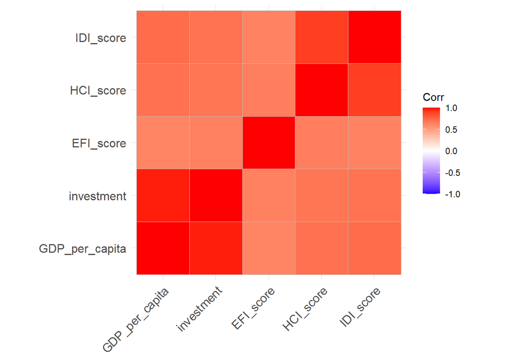

```r
correlation_analysis_countries = countries_cleaned %>% select(-year) %>% select(-country)
correlations = cor(correlation_analysis_countries)
ggcorrplot(cor(correlation_analysis_countries))
```

Note that for the purposes of running a regression analysis, only the correlations between independent variables (regressors) are important for assessing multicollinearity.

We can also observe the relationship between the economic growth determinants and GDP per capita in general across all countries to gain an idea of what to expect.

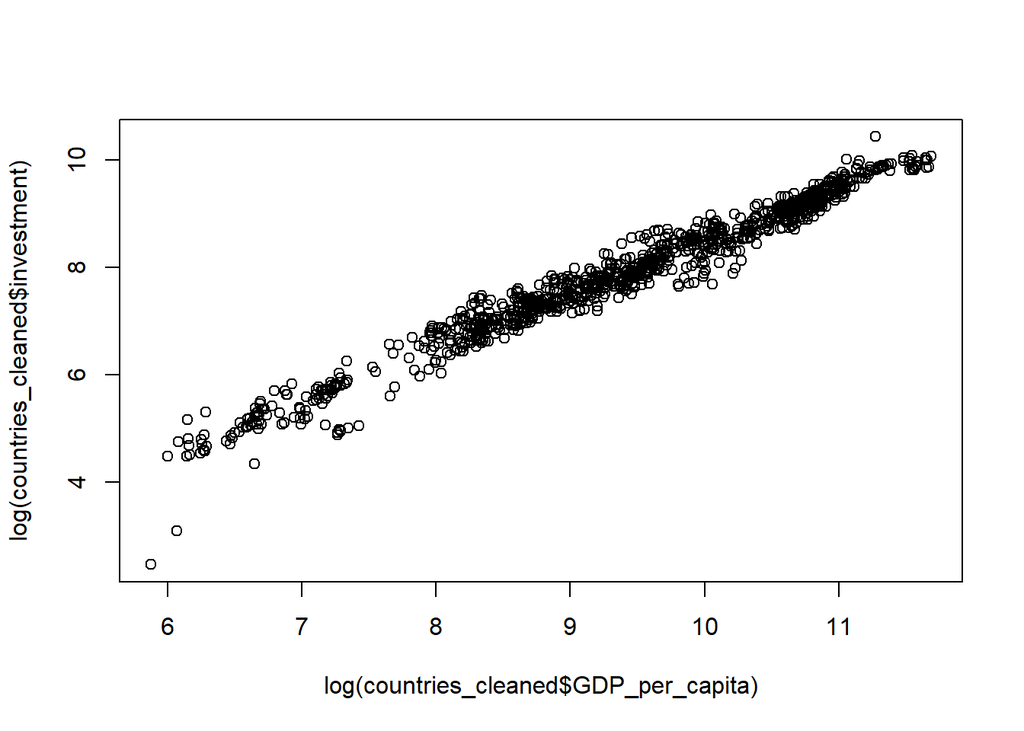

```r
plot(log(countries_cleaned$GDP_per_capita),log(countries_cleaned$investment))
```

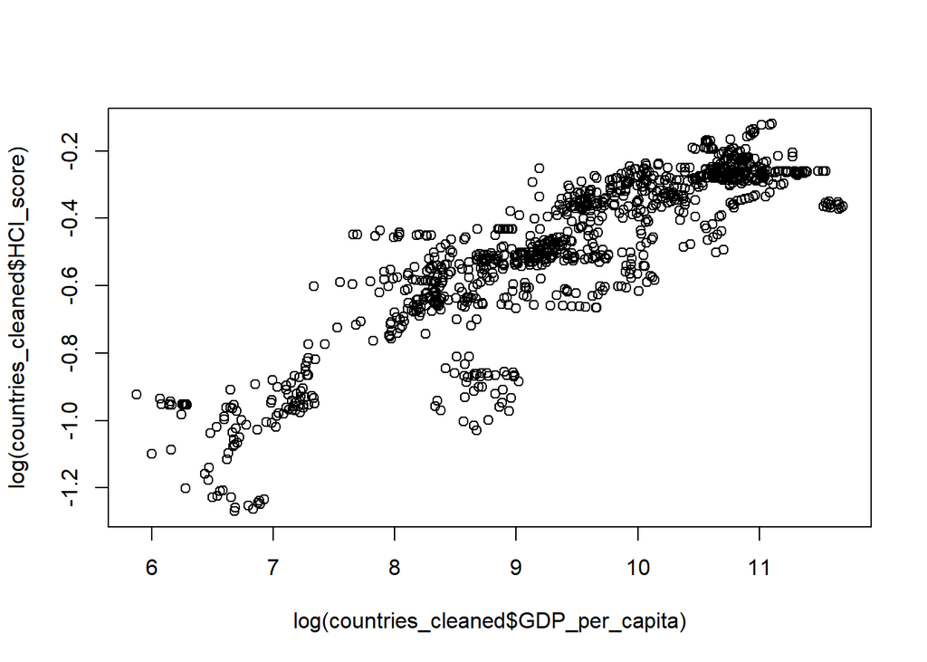

```r
plot(log(countries_cleaned$GDP_per_capita),log(countries_cleaned$HCI_score))
```

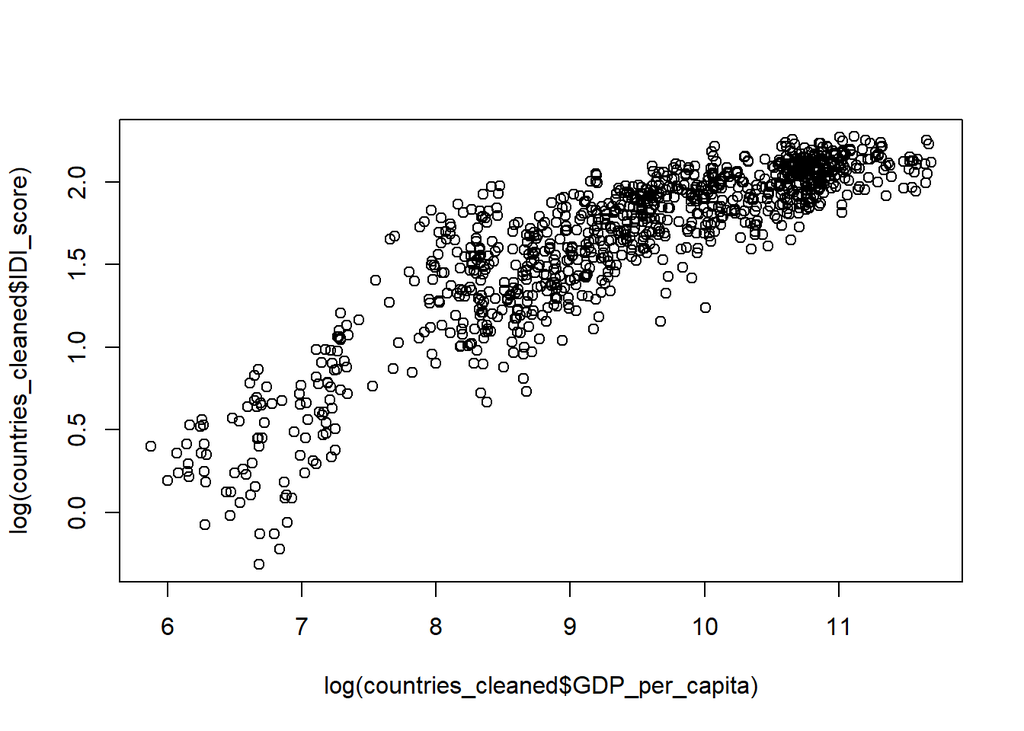

```r
plot(log(countries_cleaned$GDP_per_capita),log(countries_cleaned$IDI_score))
```

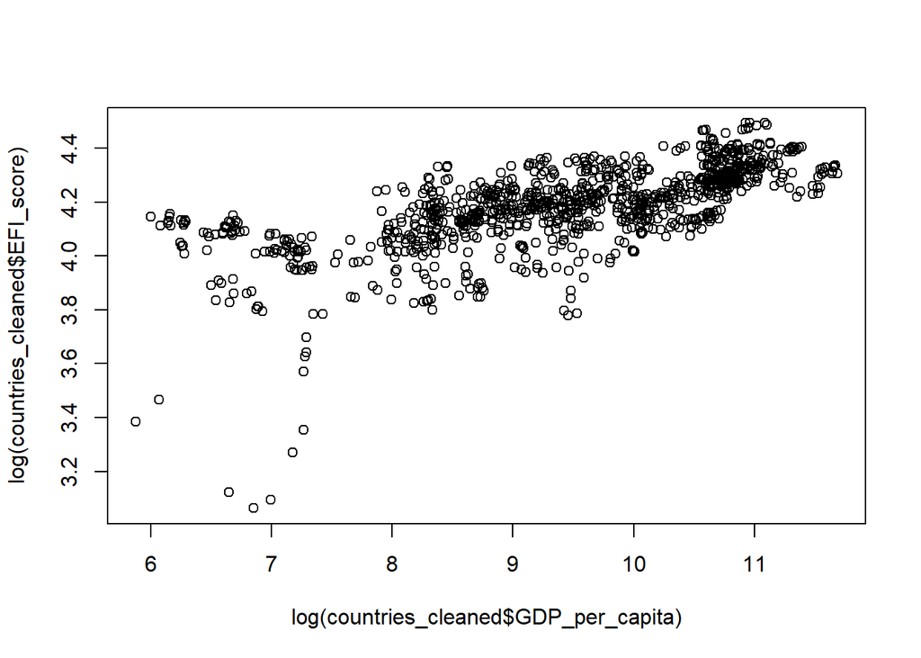

```r
plot(log(countries_cleaned$GDP_per_capita),log(countries_cleaned$EFI_score))
```

This paper analyses the determinants of economic growth by level of economic development as growth factors are likely to vary across levels of development due to having structurally different economies. We classify countries in our dataset into 4 groups from 1 (most developed) to 4 (least developed) based on their average ranking in the Economic Complexity Index (ECI) over the 13 year dataset period.

```r
G1_countries = countries_cleaned %>% filter(country %in% c('Austria', 'Belgium', 'Switzerland', 'Czech Republic', 'Germany', 'Denmark', 'Finland', 'France', 'United Kingdom', 'Hungary', 'Ireland', 'Italy', 'Japan', 'Mexico', 'Singapore', 'Slovenia', 'Sweden', 'United States', 'Luxembourg'))

G2_countries = countries_cleaned %>% filter(country %in% c('Bulgaria', 'Canada', 'Cyprus', 'Spain', 'Estonia', 'Croatia', 'Israel', 'Lithuania', 'Latvia', 'Malaysia', 'Netherlands', 'Norway', 'Panama', 'Poland', 'Portugal', 'Romania', 'Thailand', 'Turkey', 'Iceland', 'Malta'))

G3_countries = countries_cleaned %>% filter(country %in% c('Albania', 'United Arab Emirates', 'Argentina', 'Australia', 'Bahrain', 'Brazil', 'Chile', 'Colombia', 'Costa Rica', 'Georgia', 'Greece', 'Indonesia', 'Jordan', 'Moldova', 'Mauritius', 'Namibia', 'New Zealand', 'Saudi Arabia', 'Tunisia', 'Ukraine', 'Uruguay', 'South Africa'))

G4_countries = countries_cleaned %>% filter(country %in% c('Azerbaijan', 'Burkina Faso', 'Botswana', 'Cameroon', 'Algeria', 'Ecuador', 'Kazakhstan', 'Morocco', 'Madagascar', 'Oman', 'Peru', 'Paraguay', 'Senegal', 'Uganda', 'Zimbabwe'))
```

The following table shows the countries in each group.

```r
country_groups_table <- data.frame(Country = c("1", "2", "3", "4","5","6","7","8","9","10","11","12","13","14","15","16","17","18","19","20","21","22"), Group1_Countries = c('Austria', 'Belgium', 'Switzerland', 'Czech Republic', 'Germany', 'Denmark', 'Finland', 'France', 'United Kingdom', 'Hungary', 'Ireland', 'Italy', 'Japan', 'Mexico', 'Singapore', 'Slovenia', 'Sweden', 'United States', 'Luxembourg', '', '', ''), Group2_Countries = c('Bulgaria', 'Canada', 'Cyprus', 'Spain', 'Estonia', 'Croatia', 'Israel', 'Lithuania', 'Latvia', 'Malaysia', 'Netherlands', 'Norway', 'Panama', 'Poland', 'Portugal', 'Romania', 'Thailand', 'Turkey', 'Iceland', 'Malta', '', ''), Group3_Countries = c('Albania', 'United Arab Emirates', 'Argentina', 'Australia', 'Bahrain', 'Brazil', 'Chile', 'Colombia', 'Costa Rica', 'Georgia', 'Greece', 'Indonesia', 'Jordan', 'Moldova', 'Mauritius', 'Namibia', 'New Zealand', 'Saudi Arabia', 'Tunisia', 'Ukraine', 'Uruguay', 'South Africa'), Group4_Countries = c('Azerbaijan', 'Burkina Faso', 'Botswana', 'Cameroon', 'Algeria', 'Ecuador', 'Kazakhstan', 'Morocco', 'Madagascar', 'Oman', 'Peru', 'Paraguay', 'Senegal', 'Uganda', 'Zimbabwe', '', '', '', '', '', '', ''))
```

```r
kable(country_groups_table, caption = "List of countries in each group") %>% kable_styling()
```

List of countries in each group

| Country | Group1_Countries | Group2_Countries | Group3_Countries | Group4_Countries |
| --- | --- | --- | --- | --- |
| 1 | Austria | Bulgaria | Albania | Azerbaijan |
| 2 | Belgium | Canada | United Arab Emirates | Burkina Faso |
| 3 | Switzerland | Cyprus | Argentina | Botswana |
| 4 | Czech Republic | Spain | Australia | Cameroon |
| 5 | Germany | Estonia | Bahrain | Algeria |
| 6 | Denmark | Croatia | Brazil | Ecuador |
| 7 | Finland | Israel | Chile | Kazakhstan |
| 8 | France | Lithuania | Colombia | Morocco |
| 9 | United Kingdom | Latvia | Costa Rica | Madagascar |
| 10 | Hungary | Malaysia | Georgia | Oman |
| 11 | Ireland | Netherlands | Greece | Peru |
| 12 | Italy | Norway | Indonesia | Paraguay |
| 13 | Japan | Panama | Jordan | Senegal |
| 14 | Mexico | Poland | Moldova | Uganda |
| 15 | Singapore | Portugal | Mauritius | Zimbabwe |
| 16 | Slovenia | Romania | Namibia |  |
| 17 | Sweden | Thailand | New Zealand |  |
| 18 | United States | Turkey | Saudi Arabia |  |
| 19 | Luxembourg | Iceland | Tunisia |  |
| 20 |  | Malta | Ukraine |  |
| 21 |  |  | Uruguay |  |
| 22 |  |  | South Africa |  |

The number of observations for each group:

```r
nrow(G1_countries)
```

```
## [1] 247
```

```r
nrow(G2_countries)
```

```
## [1] 260
```

```r
nrow(G3_countries)
```

```
## [1] 286
```

```r
nrow(G4_countries)
```

```
## [1] 195
```

As we can see, we have the least data for the least developed countries which is to be expected.

# Methodology

## Multiple Linear Regression Model

Multiple linear regression analysis is used for each group of countries to analyze the relative importance of economic growth determinants. For each regression the natural logarithm of all variables is taken as the figures for different factors vary greatly in magnitude and so this can help reduce the impact of heteroskedasticity. By having panel data, fixed effects regression analysis can be used to control for heterogenous time-invariant attributes across countries. The Hausman test (Hausman, 1978) is used to decide whether to use fixed or random effects where the null hypothesis is that the preferred model is random effects and fixed effects being the preferred model under the alternative hypothesis. This test essentially analyses whether the unique errors are correlated with the regressors, which the null hypothesis argues are not. For each regression the p-value is less than 0.05 and so at the 5% significance level the null hypothesis is rejected and a fixed effects model is adopted. Tests to include time effects are similarly conducted with the conclusion being that time effects should be included in all models at the 5% significance level.

```r
fixedG1 <- plm(log(GDP_per_capita) ~ log(investment) + log(EFI_score) + log(IDI_score) + log(HCI_score), data=G1_countries, index=c("country", "year"), model="within")
randomG1 <- plm(log(GDP_per_capita) ~ log(investment) + log(EFI_score) + log(IDI_score) + log(HCI_score), data=G1_countries, index=c("country", "year"), model="random")
phtest(fixedG1, randomG1)
```

```
##
##  Hausman Test
##
## data:  log(GDP_per_capita) ~ log(investment) + log(EFI_score) + log(IDI_score) +  ...
## chisq = 2096.9, df = 4, p-value < 0.00000000000000022
## alternative hypothesis: one model is inconsistent
```

Therefore, as the p-value < 0.05, we can reject the null hypothesis at the 5% significance level and conclude that we should use a fixed effects model.

```r
fixedG2 <- plm(log(GDP_per_capita) ~ log(investment) + log(EFI_score) + log(IDI_score) + log(HCI_score), data=G2_countries, index=c("country", "year"), model="within")
randomG2 <- plm(log(GDP_per_capita) ~ log(investment) + log(EFI_score) + log(IDI_score) + log(HCI_score), data=G2_countries, index=c("country", "year"), model="random")
phtest(fixedG2, randomG2)
```

```
##
##  Hausman Test
##
## data:  log(GDP_per_capita) ~ log(investment) + log(EFI_score) + log(IDI_score) +  ...
## chisq = 63.376, df = 4, p-value = 0.0000000000005656
## alternative hypothesis: one model is inconsistent
```

Therefore, as the p-value < 0.05, we can reject the null hypothesis at the 5% significance level and conclude that we should use a fixed effects model.

```r
fixedG3 <- plm(log(GDP_per_capita) ~ log(investment) + log(EFI_score) + log(IDI_score) + log(HCI_score), data=G3_countries, index=c("country", "year"), model="within")
randomG3 <- plm(log(GDP_per_capita) ~ log(investment) + log(EFI_score) + log(IDI_score) + log(HCI_score), data=G3_countries, index=c("country", "year"), model="random")
phtest(fixedG3, randomG3)
```

```
##
##  Hausman Test
##
## data:  log(GDP_per_capita) ~ log(investment) + log(EFI_score) + log(IDI_score) +  ...
## chisq = 52.996, df = 4, p-value = 0.00000000008538
## alternative hypothesis: one model is inconsistent
```

Therefore, as the p-value < 0.05, we can reject the null hypothesis at the 5% significance level and conclude that we should use a fixed effects model.

```r
fixedG4 <- plm(log(GDP_per_capita) ~ log(investment) + log(EFI_score) + log(IDI_score) + log(HCI_score), data=G4_countries, index=c("country", "year"), model="within")
randomG4 <- plm(log(GDP_per_capita) ~ log(investment) + log(EFI_score) + log(IDI_score) + log(HCI_score), data=G4_countries, index=c("country", "year"), model="random")
phtest(fixedG4, randomG4)
```

```
##
##  Hausman Test
##
## data:  log(GDP_per_capita) ~ log(investment) + log(EFI_score) + log(IDI_score) +  ...
## chisq = 105.62, df = 4, p-value < 0.00000000000000022
## alternative hypothesis: one model is inconsistent
```

Therefore, as the p-value < 0.05, we can reject the null hypothesis at the 5% significance level and conclude that we should use a fixed effects model.

Now we similarly test as to whether we should include time effects in the model:

```r
fixed.timeG1 <- plm(log(GDP_per_capita) ~ log(investment) + log(EFI_score) + log(IDI_score) + log(HCI_score) + factor(year), data=G1_countries, index=c("country","year"), model="within")
pFtest(fixed.timeG1, fixedG1)
```

```
##
##  F test for individual effects
##
## data:  log(GDP_per_capita) ~ log(investment) + log(EFI_score) + log(IDI_score) +  ...
## F = 7.1893, df1 = 12, df2 = 212, p-value = 0.00000000005602
## alternative hypothesis: significant effects
```

Therefore, as the p-value < 0.05, we can reject the null hypothesis at the 5% significance level and conclude that we should include time effects.

```r
fixed.timeG2 <- plm(log(GDP_per_capita) ~ log(investment) + log(EFI_score) + log(IDI_score) + log(HCI_score) + factor(year), data=G2_countries, index=c("country","year"), model="within")
pFtest(fixed.timeG2, fixedG2)
```

```
##
##  F test for individual effects
##
## data:  log(GDP_per_capita) ~ log(investment) + log(EFI_score) + log(IDI_score) +  ...
## F = 5.1125, df1 = 12, df2 = 224, p-value = 0.0000001532
## alternative hypothesis: significant effects
```

Therefore, as the p-value < 0.05, we can reject the null hypothesis at the 5% significance level and conclude that we should include time effects.

```r
fixed.timeG3 <- plm(log(GDP_per_capita) ~ log(investment) + log(EFI_score) + log(IDI_score) + log(HCI_score) + factor(year), data=G3_countries, index=c("country","year"), model="within")
pFtest(fixed.timeG3, fixedG3)
```

```
##
##  F test for individual effects
##
## data:  log(GDP_per_capita) ~ log(investment) + log(EFI_score) + log(IDI_score) +  ...
## F = 6.5507, df1 = 12, df2 = 248, p-value = 0.000000000377
## alternative hypothesis: significant effects
```

Therefore, as the p-value < 0.05, we can reject the null hypothesis at the 5% significance level and conclude that we should include time effects.

```r
fixed.timeG4 <- plm(log(GDP_per_capita) ~ log(investment) + log(EFI_score) + log(IDI_score) + log(HCI_score) + factor(year), data=G4_countries, index=c("country","year"), model="within")
pFtest(fixed.timeG4, fixedG4)
```

```
##
##  F test for individual effects
##
## data:  log(GDP_per_capita) ~ log(investment) + log(EFI_score) + log(IDI_score) +  ...
## F = 5.0605, df1 = 12, df2 = 164, p-value = 0.0000003818
## alternative hypothesis: significant effects
```

Therefore, as the p-value < 0.05, we can reject the null hypothesis at the 5% significance level and conclude that we should include time effects.

Therefore, each regression model includes both time and country fixed effects. There are no further control variables but by using fixed effects multiple linear regression analysis, the regressor coefficients will automatically show the associated impact of each economic growth determinant on output while controlling for all the other growth factors and exogenous time-invariant heterogeneities across countries as well as variables which are constant across countries but vary over time. Thus, formally, the entity and time fixed effects regression model for each group of countries is as follows:

$$ln(y_{it})= β_0+β_1ln(k_{it})+β_2ln(h_{it})+β_3ln(z_{p_{it}})+β_4ln(z_{s_{it}})+γ_2D2_i+...+γ_nDn_i+δ_2 B2_t+...+δ_T BT_t+e_{it}$$

where:

$γ_n Dn_i$ = Dummy variable for nth country in dataset. These country dummy variables control for unobserved time-invariant heterogeneities across countries.

$δ_t BT_t$ = Dummy variable for year t in dataset. These time dummy variables control for variables that are constant across entities but vary over time.

$e_{it}$ = Residual error term between the true observed value and the model’s fitted value.

There are only n−1 country and t-1 time dummies (i.e. $γ_1 D1_i$ and $δ_1 B1_t$ are omitted) as the regression model already includes an intercept $β_0$.

The regression model can be simplified in notation as follows:

$$ln(y_{it})=β_1ln(k_{it})+β_2ln(h_{it})+β_3ln(z_{p_{it}})+β_4ln(z_{s_{it}})+α_i+δ_t+e_{it}$$

where: $α_i$ = Entity fixed effect i.e. country-specific intercepts that capture time-invariant heterogeneities across countries e.g. country climates, cultures.

$δ_t$ = Time fixed effect i.e. time-specific intercepts that capture differences in log GDP per capita that vary across time periods but not across individual countries e.g. global macroeconomic conditions like the impact of the Covid-19 pandemic.

To estimate the regression coefficients: $(β_0,β_1,β_2,β_3,β_4 )$ we use the ordinary least squares (OLS) method with fixed effects. The OLS method minimizes the sum of the squares of the residuals (differences between observed dependent variables and the values predicted by the function of independent variables and fixed effects) which mathematically is as follows:

$$min(∑_ie_{it}^2 )=min(∑_i(ln(y_{it})-\hat{ln(y_{it})} )^2 )$$
$$\sum_{i} [ln(y_{it})-(β_0+β_1ln(k_{it})+β_2ln(h_{it})+β_3ln(z_{p_{it}})+β_4ln(z_{s_{it}})+γ_2D2_i+...+γ_nDn_i+δ_2 B2_t+...+δ_T BT_t)]^2$$

Or

$$\sum_{i} [ln(y_{it})-(β_1ln(k_{it})+β_2ln(h_{it})+β_3ln(z_{p_{it}})+β_4ln(z_{s_{it}})+α_i+δ_t)]^2$$

Provided the fixed effects regression assumptions hold, the sampling distribution of the OLS estimator in the fixed effects regression model is normal in large samples. Thus, the variance of the estimates can be estimated and standard errors, t-statistics and confidence intervals computed for the coefficients.

## Testing Regression Assumptions

The following regression assumptions must hold for the best inference from the fixed effects regression models:

1. No multicollinearity
   2. Linearity
   3. Normally distributed errors
   4. Independent error terms (no autocorrelation)
   5. Homoskedasticity (constant error variance)
   6. No exogeneity

The following measures are used to test if the regression models satisfy each assumption.

### Assumption 1: Multicollinearity

While multicollinearity does not reduce the predictive power of a model it alters the coefficients of individual regressors of which we are interested in knowing for measuring the importance of each of the economic growth determinants as countries develop. The Pearson correlation coefficient between regressors is used to test for multicollinearity with a maximum permitted correlation coefficient of 0.75, otherwise at least one of the regressors is dropped from the model.

### Assumption 2: Linearity

Linearity means the dependent variable is a linear combination of the regression coefficients and predictor variables. This ensures we are using the correct functional form to model the relationship between the dependent variable (GDP per capita) and the predictor variables (the economic growth determinants). A plot of the residuals versus predicted GDP per capita value from the regression model is used to test for linearity. If the residuals are plotted fairly evenly around the zero line, then the model exhibits an acceptable degree of linearity.

### Assumption 3: Normality of error terms

Non-normality of error terms will impact the standard error of regression coefficients which impacts whether a growth determinant is statistically significant. To assess the normality of error terms a histogram and Q-Q plot of the residuals is used. If there is normality, the histogram should display a normal distribution. A Q-Q plot is a scatterplot created by plotting two sets of quantiles against one another. If both sets of quantiles come from the same distribution i.e. the error terms are normally distributed, the points should form a line that’s roughly straight.

### Assumption 4: Independent Error Terms (No Autocorrelation)

Autocorrelation is a degree of similarity between a given time series and a lagged version of itself over successive time intervals. If a regression model exhibits autocorrelation, this impacts the standard errors of the coefficients thereby impacting whether a regressor term is statistically significant. The Breusch-Godfrey test (Breusch, 1978) is used to test for autocorrelated errors in the regression model. The Breusch-Godfrey test has the following null and alternative hypotheses:

$H_0$: no autocorrelation exists

$H_1$: autocorrelation exists

If the p-value < 0.05, then at the 5% significance level the null hypothesis is rejected, and we conclude that autocorrelation exists.

### Assumption 5: Constant Error Variance (Homoskedasticity)

Heteroskedasticity is when the standard deviations of a predicted variable, as calculated over different values of an independent variable(s) or as related to prior time periods is not constant. With homoskedasticity, the Gaussian Markov theorem ensures that each least-squares estimator is the best linear unbiased estimator. To have homoskedasticity, all the variances of the error terms must be constant and not depend on the covariates, which means that each probability distribution of the response variable has the same variance regardless of the covariates. Mathematically, this is expressed as follows:

$$E(e│x)=0$$
$$E(e^2│X)= σ^2$$
$$∴Var(e│X)=E(e^2│X)-E(e│X)^2=σ^2$$

If heteroskedasticity is present, this impacts the standard errors of regressor coefficients and thus whether a regressor variable is statistically significant. The Breusch-Pagan test is used to test for heteroskedasticity (Breusch; Pagan, 1979) which has the following null and alternative hypotheses:

$H_0$: the error variances are all equal

$H_1$: the error variances are not equal

If the p-value < 0.05, then at the 5% significance level the null hypothesis is rejected, and we conclude that heteroskedasticity exists. Most of the fixed effects regression models in this paper exhibit both heteroskedasticity and autocorrelation. This means that while the regressor coefficients are still unbiased the standard errors are wrong (usually understating the true uncertainty). To correct for this, clustered standard errors are used which are a form of heteroskedasticity and autocorrelation-consistent standard errors. Clustered standard errors allow the regression error terms to have an arbitrary correlation within a grouping but assume that the regression errors are uncorrelated across groups. Clustered standard errors are still valid whether or not there is heteroskedasticity, autocorrelation or both. Clustered standard errors are generated in R using the vcovHC function from the sandwich library.

### Assumption 6: No Exogeneity

Despite using the most common important economic growth determinants as control variables for one another and including country and time fixed effects, the regression models cannot control for omitted variables that vary both across countries and time. However, this paper assumes that the overall impact of such exogenous omitted variables is small.

# Regression Analysis

We now test whether the regression models satisfy the necessary assumptions.

## Most Developed (Group 1) Countries

The initial fixed effects regression model for group 1 countries is given by the following code:

```r
reg_G1_fixed <- plm(log(GDP_per_capita) ~ log(investment) + log(EFI_score) + log(IDI_score) + log(HCI_score), data=G1_countries, index=c("country", "year"), model="within", effects="twoways")
```

### Assumption 1: Multicollinearity

The Pearson correlation coefficient between regressors is used to test for multicollinearity and keep only those growth determinants with a correlation coefficient less than 0.75.

```r
corr_analysis_countriesG1 = countries_cleaned %>% filter(country %in% c('Austria', 'Belgium', 'Switzerland', 'Czech Republic', 'Germany', 'Denmark', 'Finland', 'France', 'United Kingdom', 'Hungary', 'Ireland', 'Italy', 'Japan', 'Mexico', 'Singapore', 'Slovenia', 'Sweden', 'United States', 'Luxembourg')) %>% mutate(GDP_per_capita = log(GDP_per_capita)) %>% mutate(investment = log(investment)) %>% mutate(EFI_score = log(EFI_score)) %>% mutate(IDI_score = log(IDI_score)) %>% mutate(HCI_score = log(HCI_score)) %>% select(-year) %>% select(-country)
cor(corr_analysis_countriesG1, method="pearson")
```

```
##                GDP_per_capita investment EFI_score HCI_score IDI_score
## GDP_per_capita      1.0000000  0.9675161 0.5774627 0.5079794 0.7136771
## investment          0.9675161  1.0000000 0.6108746 0.5550177 0.6785159
## EFI_score           0.5774627  0.6108746 1.0000000 0.3970563 0.3924941
## HCI_score           0.5079794  0.5550177 0.3970563 1.0000000 0.6641941
## IDI_score           0.7136771  0.6785159 0.3924941 0.6641941 1.0000000
```

As all the independent variables have correlations less than 0.75 we do not need to remove any growth determinants.

## Assumption 2: Linearity

We plot the residual vs fitted values to test for linearity in the regression model.

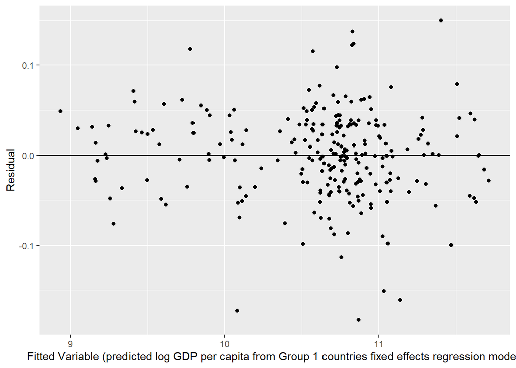

```r
resid_plot_G1_fixed = ggplot(G1_countries, aes(x= as.matrix(log(G1_countries$GDP_per_capita) - residuals(reg_G1_fixed), idbyrow = TRUE), y= as.matrix(residuals(reg_G1_fixed), idbyrow = TRUE))) + geom_point() + geom_hline(yintercept=0) + labs(x="Fitted Variable (predicted log GDP per capita from Group 1 countries fixed effects regression model)", y="Residual")
resid_plot_G1_fixed
```

As the residual vs fitted plot shows, there is a fairly even distribution around the 0-line indicating that our model has good functional form.

## Assumption 3: Normality of error terms

Plot of histogram of the error terms:

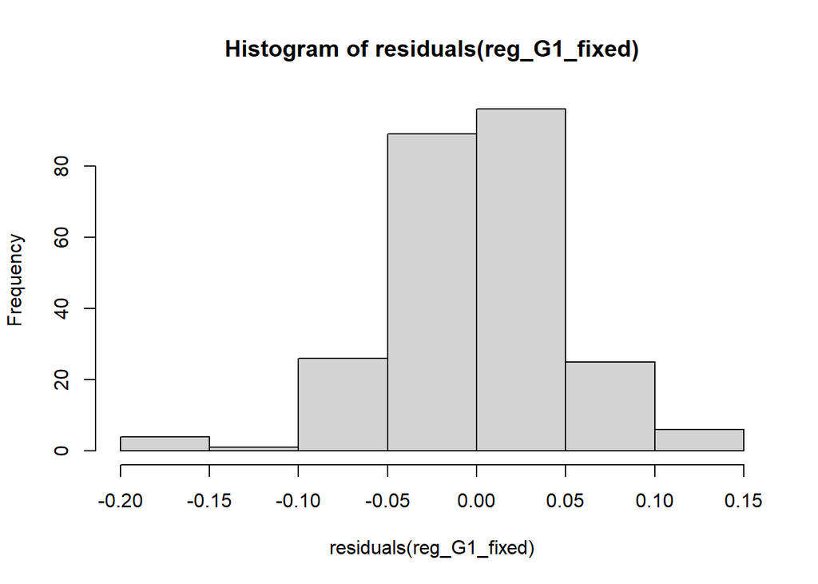

```r
hist(residuals(reg_G1_fixed))
```

Q-Q plot of error terms:

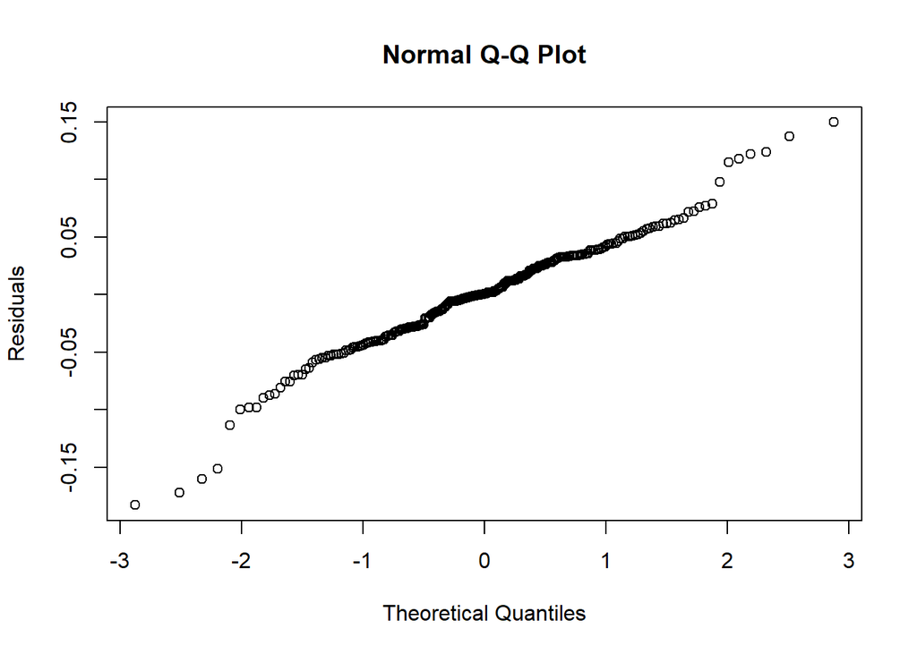

```r
qqnorm(residuals(reg_G1_fixed), ylab = 'Residuals')
```

The error terms of the regression model display a roughly normal distribution as shown by the histogram and Q-Q plot.

## Assumption 4: Independent Error Terms (No Autocorrelation) Test

The Breusch-Godfrey test returns:

```r
pbgtest(reg_G1_fixed)
```

```
##
##  Breusch-Godfrey/Wooldridge test for serial correlation in panel models
##
## data:  log(GDP_per_capita) ~ log(investment) + log(EFI_score) + log(IDI_score) +     log(HCI_score)
## chisq = 76.088, df = 13, p-value = 0.00000000005966
## alternative hypothesis: serial correlation in idiosyncratic errors
```

Therefore, at the 5% significance level there is sufficient evidence to reject the null hypothesis and conclude that the regression model exhibits autocorrelation which will thus be corrected for using robust standard errors.

## Assumption 5: Constant Error Variance (Homoskedasticity) Test

The Breusch-Pagan test returns:

```r
bptest(reg_G1_fixed)
```

```
##
##  studentized Breusch-Pagan test
##
## data:  reg_G1_fixed
## BP = 1.0872, df = 4, p-value = 0.8963
```

Therefore, at the 5% significance level there is insufficient evidence to reject the null hypothesis and thus we can conclude that the regression model does not have heteroskedasticity.

# Developed (Group 2) Countries

Our initial fixed effects regression model for group 2 countries is given by the following code:

```r
reg_G2_fixed <- plm(log(GDP_per_capita) ~ log(investment) + log(EFI_score) + log(IDI_score) + log(HCI_score), data=G2_countries, index=c("country", "year"), model="within", effects="twoways")
```

## Assumption 1: Multicollinearity

The Pearson correlation coefficient between regressors is used to test for multicollinearity and keep only those growth determinants with a correlation coefficient less than 0.75.

```r
corr_analysis_countriesG2 = countries_cleaned %>% filter(country %in% c('Bulgaria', 'Canada', 'Cyprus', 'Spain', 'Estonia', 'Croatia', 'Israel', 'Lithuania', 'Latvia', 'Malaysia', 'Netherlands', 'Norway', 'Panama', 'Poland', 'Portugal', 'Romania', 'Thailand', 'Turkey', 'Iceland', 'Malta')) %>% mutate(GDP_per_capita = log(GDP_per_capita)) %>% mutate(investment = log(investment)) %>% mutate(EFI_score = log(EFI_score)) %>% mutate(IDI_score = log(IDI_score)) %>% mutate(HCI_score = log(HCI_score)) %>% select(-year) %>% select(-country)
cor(corr_analysis_countriesG2, method="pearson")
```

```
##                GDP_per_capita investment EFI_score HCI_score IDI_score
## GDP_per_capita      1.0000000  0.9504520 0.5760025 0.7578345 0.7184349
## investment          0.9504520  1.0000000 0.5649833 0.6188324 0.6116635
## EFI_score           0.5760025  0.5649833 1.0000000 0.4979387 0.5572681
## HCI_score           0.7578345  0.6188324 0.4979387 1.0000000 0.7823195
## IDI_score           0.7184349  0.6116635 0.5572681 0.7823195 1.0000000
```

HCI is removed due to multicollinearity.

```r
 reg_G2_fixed <- plm(log(GDP_per_capita) ~ log(investment) + log(EFI_score) + log(IDI_score), data=G2_countries, index=c("country", "year"), model="within", effects="twoways")
```

## Assumption 2: Linearity

We plot the residual vs fitted values to test for linearity in the regression model.

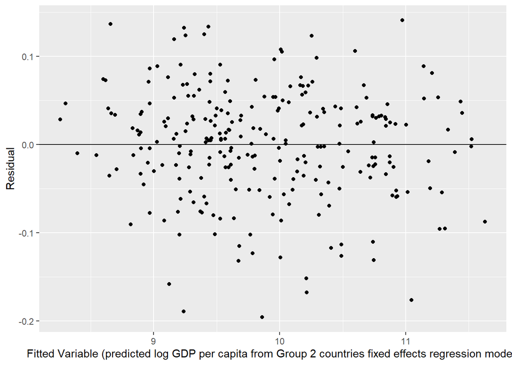

```r
resid_plot_G2_fixed = ggplot(G2_countries, aes(x= as.matrix(log(G2_countries$GDP_per_capita) - residuals(reg_G2_fixed), idbyrow = TRUE), y= as.matrix(residuals(reg_G2_fixed), idbyrow = TRUE))) + geom_point() + geom_hline(yintercept=0) + labs(x="Fitted Variable (predicted log GDP per capita from Group 2 countries fixed effects regression model)", y="Residual")
resid_plot_G2_fixed
```

As the residual vs fitted plot shows, there is a fairly even distribution around the 0-line indicating that our model has good functional form.

## Assumption 3: Normality of error terms

Plot of histogram of the error terms:

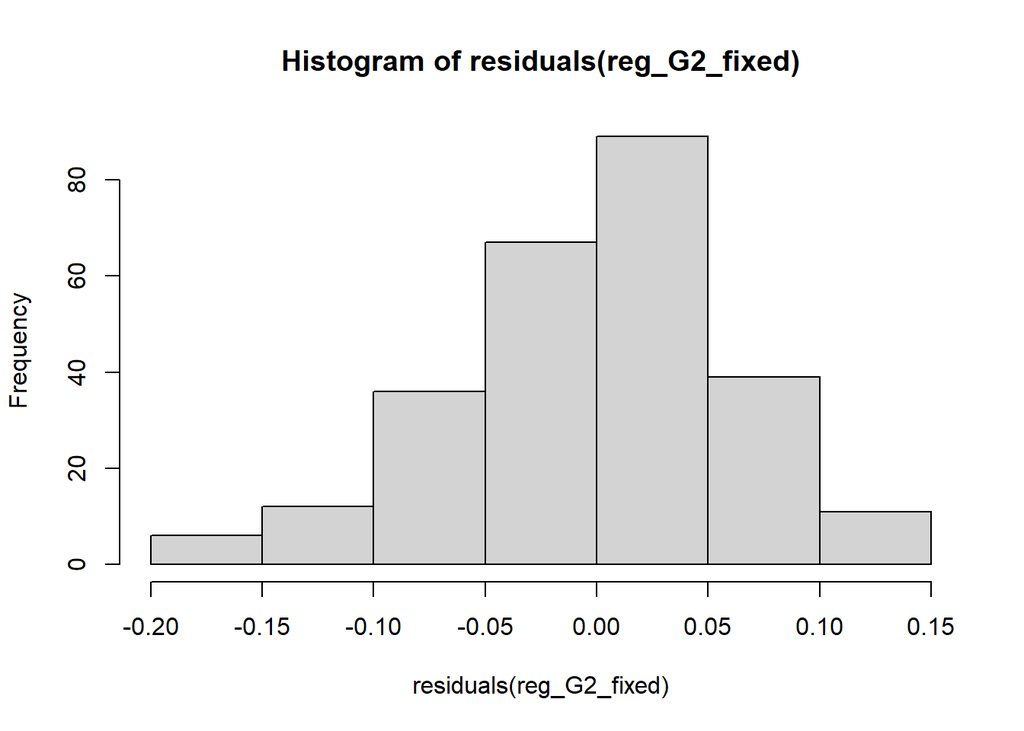

```r
hist(residuals(reg_G2_fixed))
```

Q-Q plot of error terms:

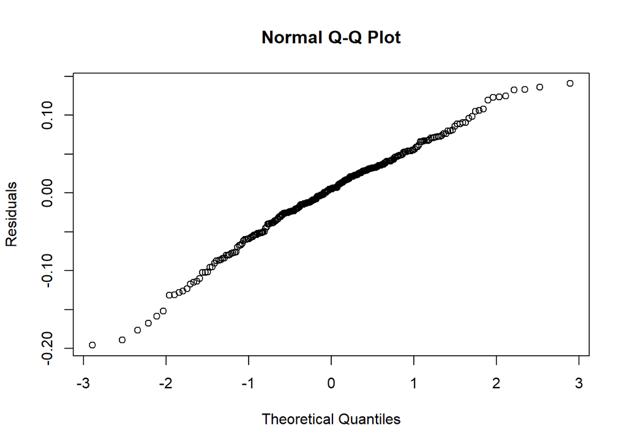

```r
qqnorm(residuals(reg_G2_fixed), ylab = 'Residuals')
```

The error terms of the regression model display a roughly normal distribution as shown by the histogram and Q-Q plot.

## Assumption 4: Independent Error Terms (No Autocorrelation) Test

The Breusch-Godfrey test returns:

```r
pbgtest(reg_G2_fixed)
```

```
##
##  Breusch-Godfrey/Wooldridge test for serial correlation in panel models
##
## data:  log(GDP_per_capita) ~ log(investment) + log(EFI_score) + log(IDI_score)
## chisq = 117.66, df = 13, p-value < 0.00000000000000022
## alternative hypothesis: serial correlation in idiosyncratic errors
```

Therefore, at the 5% significance level there is sufficient evidence to reject the null hypothesis and conclude that the regression model exhibits autocorrelation which will thus be corrected for using robust standard errors.

## Assumption 5: Constant Error Variance (Homoskedasticity) Test

The Breusch-Pagan test returns:

```r
bptest(reg_G2_fixed)
```

```
##
##  studentized Breusch-Pagan test
##
## data:  reg_G2_fixed
## BP = 4.764, df = 3, p-value = 0.1899
```

# Less Developed (Group 3) Countries

```r
reg_G3_fixed <- plm(log(GDP_per_capita) ~ log(investment) + log(EFI_score) + log(IDI_score) + log(HCI_score), data=G3_countries, index=c("country", "year"), model="within", effects="twoways")
```

## Assumption 1: Multicollinearity

The Pearson correlation coefficient between regressors is used to test for multicollinearity and keep only those growth determinants with a correlation coefficient less than 0.75.

```r
corr_analysis_countriesG3 = countries_cleaned %>% filter(country %in% c('Albania', 'United Arab Emirates', 'Argentina', 'Australia', 'Bahrain', 'Brazil', 'Chile', 'Colombia', 'Costa Rica', 'Georgia', 'Greece', 'Indonesia', 'Jordan', 'Moldova', 'Mauritius', 'Namibia', 'New Zealand', 'Saudi Arabia', 'Tunisia', 'Ukraine', 'Uruguay', 'South Africa')) %>% mutate(GDP_per_capita = log(GDP_per_capita)) %>% mutate(investment = log(investment)) %>% mutate(EFI_score = log(EFI_score)) %>% mutate(IDI_score = log(IDI_score)) %>% mutate(HCI_score = log(HCI_score)) %>% select(-year) %>% select(-country)
cor(corr_analysis_countriesG3, method="pearson")
```

```
##                GDP_per_capita investment EFI_score HCI_score IDI_score
## GDP_per_capita      1.0000000  0.9695265 0.5138992 0.6302457 0.6972739
## investment          0.9695265  1.0000000 0.5891720 0.5908814 0.6131862
## EFI_score           0.5138992  0.5891720 1.0000000 0.3986155 0.3217410
## HCI_score           0.6302457  0.5908814 0.3986155 1.0000000 0.7218330
## IDI_score           0.6972739  0.6131862 0.3217410 0.7218330 1.0000000
```

As all the independent variables have correlations less than 0.75 no variables are removed.

## Assumption 2: Linearity

We plot the residual vs fitted values to test for linearity in the regression model.

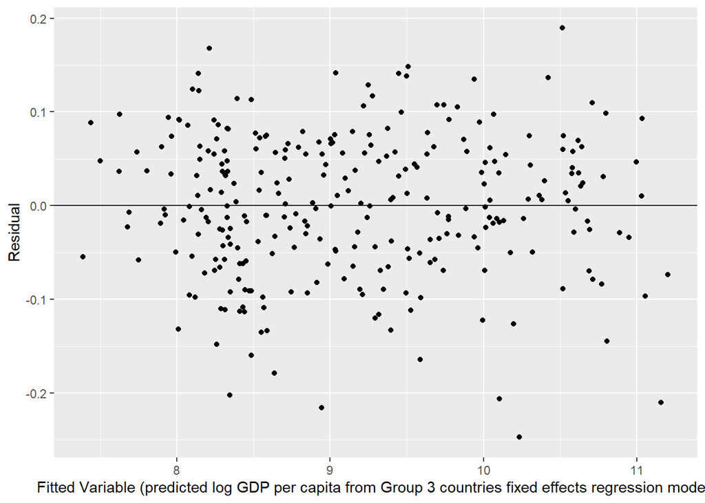

```r
resid_plot_G3_fixed = ggplot(G3_countries, aes(x= as.matrix(log(G3_countries$GDP_per_capita) - residuals(reg_G3_fixed), idbyrow = TRUE), y= as.matrix(residuals(reg_G3_fixed), idbyrow = TRUE))) + geom_point() + geom_hline(yintercept=0) + labs(x="Fitted Variable (predicted log GDP per capita from Group 3 countries fixed effects regression model)", y="Residual")
resid_plot_G3_fixed
```

As the residual vs fitted plot shows, there is a fairly even distribution around the 0-line indicating that our model has good functional form.

## Assumption 3: Normality of error terms

Plot of histogram of the error terms:

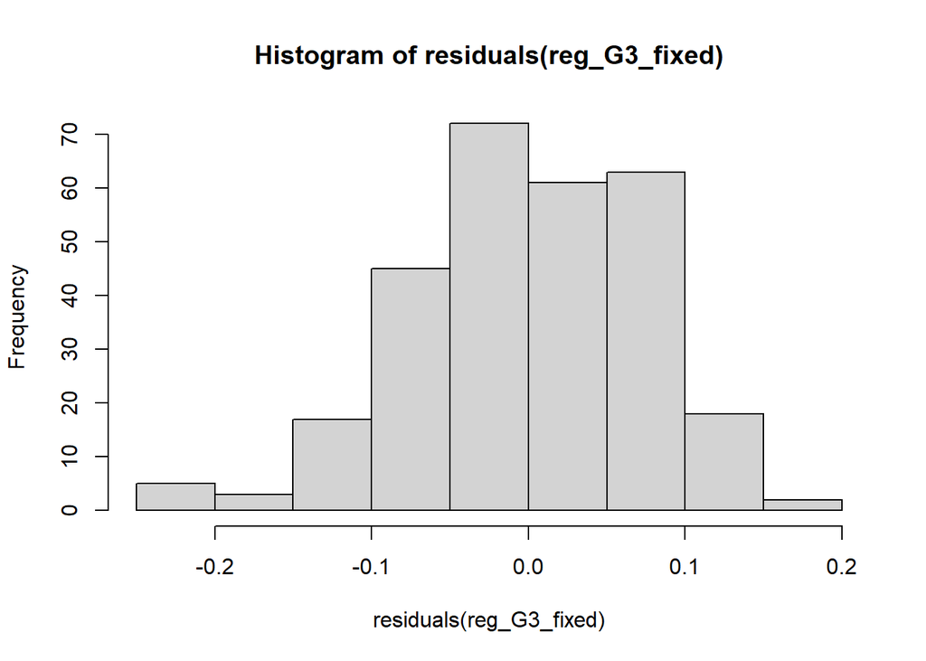

```r
hist(residuals(reg_G3_fixed))
```

Q-Q plot of error terms:

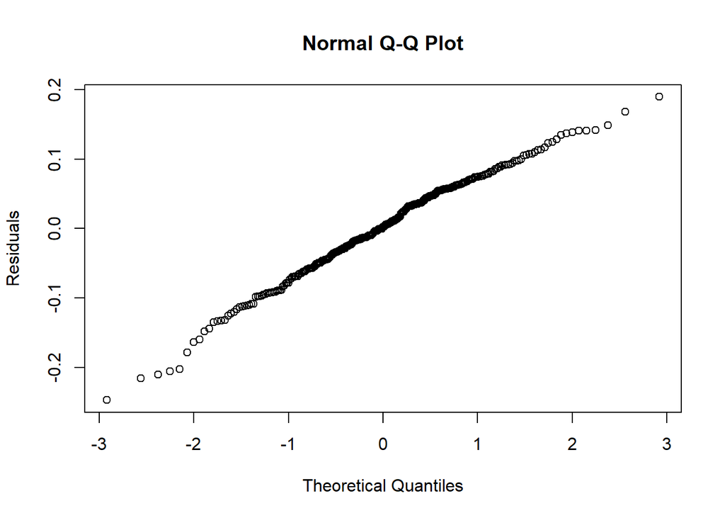

```r
qqnorm(residuals(reg_G3_fixed), ylab = 'Residuals')
```

The error terms of the regression model display a roughly normal distribution as shown by the histogram and Q-Q plot.

## Assumption 4: Independent Error Terms (No Autocorrelation) Test

The Breusch-Godfrey test returns:

```r
pbgtest(reg_G3_fixed)
```

```
##
##  Breusch-Godfrey/Wooldridge test for serial correlation in panel models
##
## data:  log(GDP_per_capita) ~ log(investment) + log(EFI_score) + log(IDI_score) +     log(HCI_score)
## chisq = 103.19, df = 13, p-value = 0.0000000000000003979
## alternative hypothesis: serial correlation in idiosyncratic errors
```

Therefore, at the 5% significance level there is sufficient evidence to reject the null hypothesis and conclude that the regression model exhibits autocorrelation which will thus be corrected for using robust standard errors.

## Assumption 5: Constant Error Variance (Homoskedasticity) Test

The Breusch-Pagan test returns:

```r
bptest(reg_G3_fixed)
```

```
##
##  studentized Breusch-Pagan test
##
## data:  reg_G3_fixed
## BP = 11.743, df = 4, p-value = 0.01937
```

Therefore, at the 5% significance level there is sufficient evidence to reject the null hypothesis and conclude that the regression model exhibits heteroskedasticity which will thus be corrected for using robust standard errors.

# Least Developed (Group 4) Countries

```r
reg_G4_fixed <- plm(log(GDP_per_capita) ~ log(investment) + log(EFI_score) + log(IDI_score) + log(HCI_score), data=G4_countries, index=c("country", "year"), model="within", effects="twoways")
```

## Assumption 1: Multicollinearity

The Pearson correlation coefficient between regressors is used to test for multicollinearity and keep only those growth determinants with a correlation coefficient less than 0.75.

```r
corr_analysis_countriesG4 = countries_cleaned %>% filter(country %in% c('Azerbaijan', 'Burkina Faso', 'Botswana', 'Cameroon', 'Algeria', 'Ecuador', 'Kazakhstan', 'Morocco', 'Madagascar', 'Oman', 'Peru', 'Paraguay', 'Senegal', 'Uganda', 'Zimbabwe', 'Burkina Faso', 'Cameroon')) %>% mutate(GDP_per_capita = log(GDP_per_capita)) %>% mutate(investment = log(investment)) %>% mutate(EFI_score = log(EFI_score)) %>% mutate(IDI_score = log(IDI_score)) %>% mutate(HCI_score = log(HCI_score)) %>% select(-year) %>% select(-country)
cor(corr_analysis_countriesG4, method="pearson")
```

```
##                GDP_per_capita investment EFI_score HCI_score IDI_score
## GDP_per_capita      1.0000000  0.9671826 0.3364193 0.8100206 0.8666488
## investment          0.9671826  1.0000000 0.4392903 0.7478245 0.8216275
## EFI_score           0.3364193  0.4392903 1.0000000 0.1373786 0.2081729
## HCI_score           0.8100206  0.7478245 0.1373786 1.0000000 0.8703283
## IDI_score           0.8666488  0.8216275 0.2081729 0.8703283 1.0000000
```

As IDI has a correlation coefficient over 0.75 with both physical capital per capita and HCI, IDI is removed from the regression model. Thus, the new fixed effects regression model is given by:

```r
 reg_G4_fixed <- plm(log(GDP_per_capita) ~ log(investment) + log(EFI_score) + log(HCI_score), data=G4_countries, index=c("country", "year"), model="within", effects="twoways")
```

## Assumption 2: Linearity

We plot the residual vs fitted values to test for linearity in the regression model.

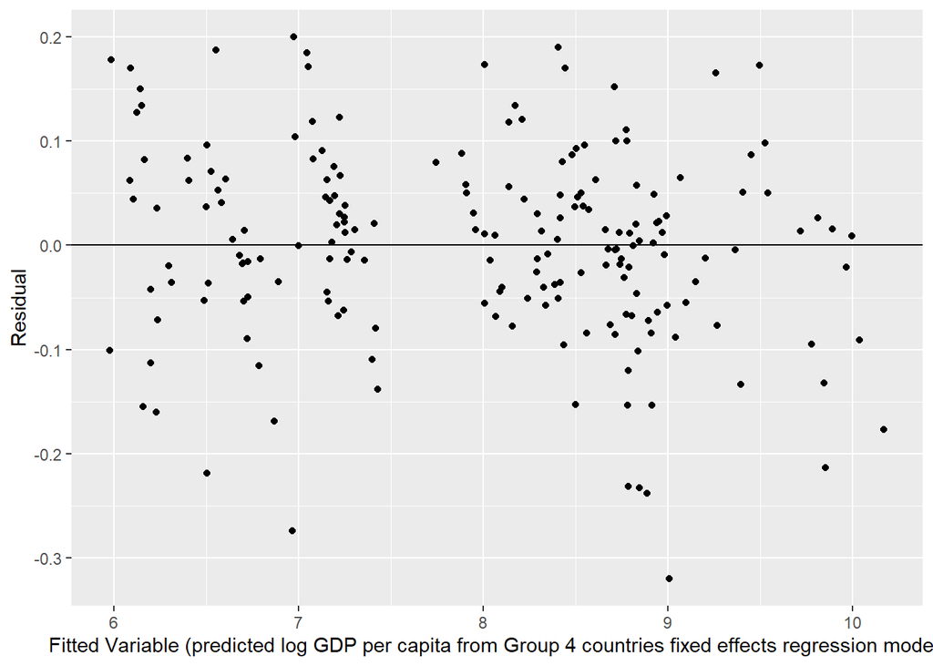

```r
resid_plot_G4_fixed = ggplot(G4_countries, aes(x= as.matrix(log(G4_countries$GDP_per_capita) - residuals(reg_G4_fixed), idbyrow = TRUE), y= as.matrix(residuals(reg_G4_fixed), idbyrow = TRUE))) + geom_point() + geom_hline(yintercept=0) + labs(x="Fitted Variable (predicted log GDP per capita from Group 4 countries fixed effects regression model)", y="Residual")
resid_plot_G4_fixed
```

As the residual vs fitted plot shows, there is a fairly even distribution around the 0 line indicating that our model has good functional form.

## Assumption 3: Normality of error terms

Plot of histogram of the error terms:

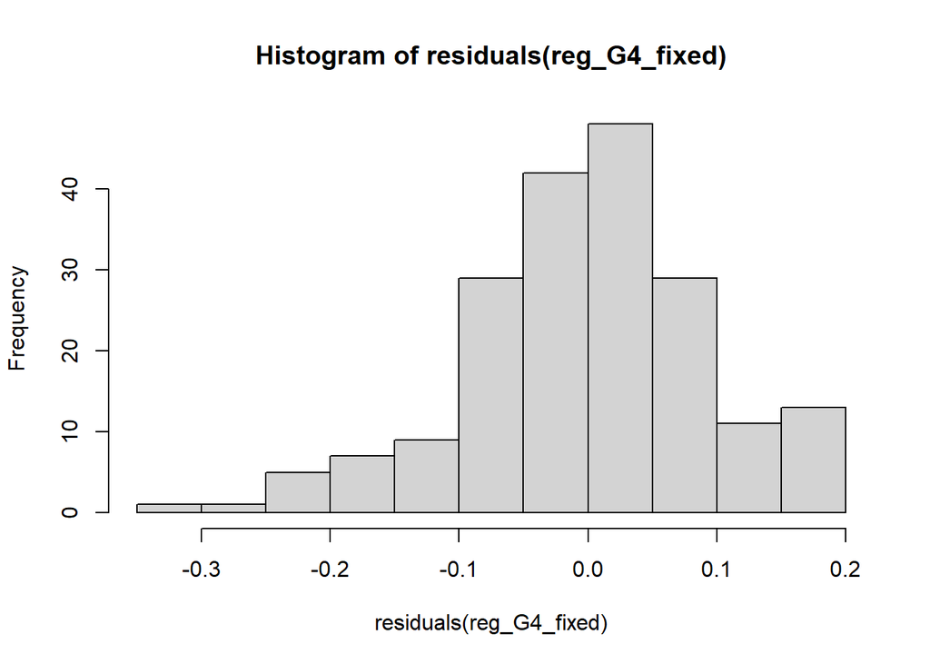

```r
hist(residuals(reg_G4_fixed))
```

Q-Q plot of error terms:

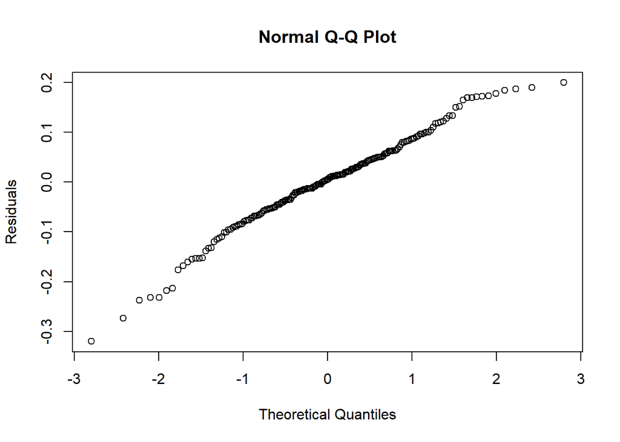

```r
qqnorm(residuals(reg_G4_fixed), ylab = 'Residuals')
```

The error terms of the regression model display a roughly normal distribution as shown by the histogram and Q-Q plot.

## Assumption 4: Independent Error Terms (No Autocorrelation) Test

The Breusch-Godfrey test returns:

```r
pbgtest(reg_G4_fixed)
```

```
##
##  Breusch-Godfrey/Wooldridge test for serial correlation in panel models
##
## data:  log(GDP_per_capita) ~ log(investment) + log(EFI_score) + log(HCI_score)
## chisq = 83.223, df = 13, p-value = 0.000000000002721
## alternative hypothesis: serial correlation in idiosyncratic errors
```

Therefore, at the 5% significance level there is sufficient evidence to reject the null hypothesis and conclude that the regression model exhibits autocorrelation which will thus be corrected for using robust standard errors.

## Assumption 5: Constant Error Variance (Homoskedasticity) Test

The Breusch-Pagan test returns:

```r
bptest(reg_G4_fixed)
```

```
##
##  studentized Breusch-Pagan test
##
## data:  reg_G4_fixed
## BP = 26.337, df = 3, p-value = 0.000008108
```

Therefore, at the 5% significance level there is sufficient evidence to reject the null hypothesis and conclude that the regression model exhibits heteroskedasticity which will thus be corrected for using robust standard errors.

# Results

As each of the regression models have now been altered to satisfy all the necessary regression assumptions, the coefficients and standard errors are reliable. Note that the p-values for each independent variable tests the null hypothesis that the regressor has no correlation with the dependent variable. If there is no correlation, then there is no association between the changes in the independent variable and shifts in the dependent variable i.e. insufficient evidence to conclude that there is an effect at the population level. This paper uses a 5% significance level to test if an independent variable is statistically significant.

## Most Developed (Group 1) Countries

The full summary table for all the regressor coefficients and supplementary statistics:

```r
summary(reg_G1_fixed)
```

```
## Oneway (individual) effect Within Model
##
## Call:
## plm(formula = log(GDP_per_capita) ~ log(investment) + log(EFI_score) +
##     log(IDI_score) + log(HCI_score), data = G1_countries, model = "within",
##     index = c("country", "year"), effects = "twoways")
##
## Balanced Panel: n = 19, T = 13, N = 247
##
## Residuals:
##        Min.     1st Qu.      Median     3rd Qu.        Max.
## -0.18293121 -0.02998604  0.00045275  0.03286511  0.14972063
##
## Coefficients:
##                 Estimate Std. Error t-value              Pr(>|t|)
## log(investment) 0.478102   0.022971 20.8130 < 0.00000000000000022 ***
## log(EFI_score)  0.345102   0.158242  2.1809              0.030236 *
## log(IDI_score)  0.110814   0.038657  2.8666              0.004545 **
## log(HCI_score)  0.356388   0.291205  1.2238              0.222299
## ---
## Signif. codes:  0 '***' 0.001 '**' 0.01 '*' 0.05 '.' 0.1 ' ' 1
##
## Total Sum of Squares:    1.9619
## Residual Sum of Squares: 0.58946
## R-Squared:      0.69955
## Adj. R-Squared: 0.67005
## F-statistic: 130.389 on 4 and 224 DF, p-value: < 0.000000000000000222
```

Adjusting for autocorrelation by using clustered standard errors we have the final coefficient table:

```r
coeftest(reg_G1_fixed, vcov = vcovHC, type = "HC1")
```

```
##
## t test of coefficients:
##
##                 Estimate Std. Error t value       Pr(>|t|)
## log(investment) 0.478102   0.078260  6.1092 0.000000004387 ***
## log(EFI_score)  0.345102   0.223040  1.5473       0.123211
## log(IDI_score)  0.110814   0.040414  2.7420       0.006601 **
## log(HCI_score)  0.356388   0.520763  0.6844       0.494457
## ---
## Signif. codes:  0 '***' 0.001 '**' 0.01 '*' 0.05 '.' 0.1 ' ' 1
```

We thus have the following regression model:

$$ln(y_{it})=0.478ln(k_{it})+0.356ln(h_{it})+0.111ln(z_{p_{it}})+0.345ln(z_{s_{it}})+α_i+δ_t+e_{it}$$

However, only capital per worker and physical productivity are statistically significant.

Therefore, in the most developed countries: A 5% increase in investment is associated, on average, with a 2.36% increase (2dp) in GDP per capita holding all other variables constant. A 5% increase in physical productivity is associated, on average, with a 0.54% increase (2dp) in GDP per capita holding all other variables constant.

The adjusted $R^2$ of the regression model is: 0.67005.

## Developed (Group 2) Countries

The full summary table for all the regressor coefficients and supplementary statistics:

```r
summary(reg_G2_fixed)
```

```
## Oneway (individual) effect Within Model
##
## Call:
## plm(formula = log(GDP_per_capita) ~ log(investment) + log(EFI_score) +
##     log(IDI_score), data = G2_countries, model = "within", index = c("country",
##     "year"), effects = "twoways")
##
## Balanced Panel: n = 20, T = 13, N = 260
##
## Residuals:
##       Min.    1st Qu.     Median    3rd Qu.       Max.
## -0.1957890 -0.0354597  0.0050607  0.0404851  0.1407737
##
## Coefficients:
##                 Estimate Std. Error t-value            Pr(>|t|)
## log(investment) 0.484998   0.018775 25.8321 <0.0000000000000002 ***
## log(EFI_score)  0.232258   0.145564  1.5956              0.1119
## log(IDI_score)  0.369310   0.032905 11.2236 <0.0000000000000002 ***
## ---
## Signif. codes:  0 '***' 0.001 '**' 0.01 '*' 0.05 '.' 0.1 ' ' 1
##
## Total Sum of Squares:    5.3321
## Residual Sum of Squares: 0.99909
## R-Squared:      0.81263
## Adj. R-Squared: 0.79524
## F-statistic: 342.625 on 3 and 237 DF, p-value: < 0.000000000000000222
```

Adjusting for heteroskedasticity and autocorrelation by using clustered standard errors we have the final coefficient table:

```r
coeftest(reg_G2_fixed, vcov = vcovHC, type = "HC1")
```

```
##
## t test of coefficients:
##
##                 Estimate Std. Error t value              Pr(>|t|)
## log(investment) 0.484998   0.031805 15.2489 < 0.00000000000000022 ***
## log(EFI_score)  0.232258   0.230766  1.0065                0.3152
## log(IDI_score)  0.369310   0.065208  5.6635         0.00000004275 ***
## ---
## Signif. codes:  0 '***' 0.001 '**' 0.01 '*' 0.05 '.' 0.1 ' ' 1
```

We thus have the following regression model:

$$ln(y_{it})=0.485ln(k_{it})+0.369ln(z_{p_{it}})+0.232ln(z_{s_{it}})+α_i+δ_t+e_{it}$$

However, only capital per worker and physical productivity are statistically significant.

## Less Developed (Group 3) Countries

The full summary table for all the regressor coefficients and supplementary statistics:

```r
summary(reg_G3_fixed)
```

```
## Oneway (individual) effect Within Model
##
## Call:
## plm(formula = log(GDP_per_capita) ~ log(investment) + log(EFI_score) +
##     log(IDI_score) + log(HCI_score), data = G3_countries, model = "within",
##     index = c("country", "year"), effects = "twoways")
##
## Balanced Panel: n = 22, T = 13, N = 286
##
## Residuals:
##       Min.    1st Qu.     Median    3rd Qu.       Max.
## -0.2471625 -0.0495284  0.0021785  0.0571561  0.1896138
##
## Coefficients:
##                   Estimate Std. Error t-value            Pr(>|t|)
## log(investment)  0.5595072  0.0219947 25.4383 <0.0000000000000002 ***
## log(EFI_score)   0.0062484  0.1257740  0.0497              0.9604
## log(IDI_score)   0.4103559  0.0313670 13.0824 <0.0000000000000002 ***
## log(HCI_score)  -0.1805835  0.2375740 -0.7601              0.4479
## ---
## Signif. codes:  0 '***' 0.001 '**' 0.01 '*' 0.05 '.' 0.1 ' ' 1
##
## Total Sum of Squares:    8.8703
## Residual Sum of Squares: 1.6358
## R-Squared:      0.81559
## Adj. R-Squared: 0.79786
## F-statistic: 287.477 on 4 and 260 DF, p-value: < 0.000000000000000222
```

Adjusting for heteroskedasticity and autocorrelation by using clustered standard errors we have the final coefficient table:

```r
coeftest(reg_G3_fixed, vcov = vcovHC, type = "HC1")
```

```
##
## t test of coefficients:
##
##                   Estimate Std. Error t value              Pr(>|t|)
## log(investment)  0.5595072  0.0442448 12.6457 < 0.00000000000000022 ***
## log(EFI_score)   0.0062484  0.2251412  0.0278                0.9779
## log(IDI_score)   0.4103559  0.0693647  5.9159         0.00000001036 ***
## log(HCI_score)  -0.1805835  0.4155118 -0.4346                0.6642
## ---
## Signif. codes:  0 '***' 0.001 '**' 0.01 '*' 0.05 '.' 0.1 ' ' 1
```

We thus have the following regression model:

$$ln(y_{it})=0.560ln(k_{it})-0.181ln(h_{it})+0.410ln(z_{p_{it}})+0.006ln(z_{s_{it}})+α_i+δ_t+e_{it}$$

However, only capital per worker and physical productivity are statistically significant.

Therefore, in less developed countries: A 5% increase in investment is associated, on average, with a 2.77% increase (2dp) in GDP per capita holding all other variables constant. A 5% increase in physical productivity is associated, on average, with a 2.02% increase (2dp) in GDP per capita holding all other variables constant.

The adjusted $R^2$ of the regression model is: 0.79786.

## Least Developed (Group 4) Countries

The full summary table for all the regressor coefficients and supplementary statistics:

```r
summary(reg_G4_fixed)
```

```
## Oneway (individual) effect Within Model
##
## Call:
## plm(formula = log(GDP_per_capita) ~ log(investment) + log(EFI_score) +
##     log(HCI_score), data = G4_countries, model = "within", index = c("country",
##     "year"), effects = "twoways")
##
## Balanced Panel: n = 15, T = 13, N = 195
##
## Residuals:
##       Min.    1st Qu.     Median    3rd Qu.       Max.
## -0.3199559 -0.0532180  0.0056404  0.0546306  0.1997657
##
## Coefficients:
##                 Estimate Std. Error t-value              Pr(>|t|)
## log(investment) 0.581034   0.025701 22.6073 < 0.00000000000000022 ***
## log(EFI_score)  0.472326   0.097647  4.8371           0.000002852 ***
## log(HCI_score)  0.282886   0.154743  1.8281               0.06922 .
## ---
## Signif. codes:  0 '***' 0.001 '**' 0.01 '*' 0.05 '.' 0.1 ' ' 1
##
## Total Sum of Squares:    7.8599
## Residual Sum of Squares: 1.6704
## R-Squared:      0.78747
## Adj. R-Squared: 0.76706
## F-statistic: 218.61 on 3 and 177 DF, p-value: < 0.000000000000000222
```

Adjusting for heteroskedasticity and autocorrelation by using clustered standard errors we have the final coefficient table:

```r
coeftest(reg_G4_fixed, vcov = vcovHC, type = "HC1")
```

```
##
## t test of coefficients:
##
##                 Estimate Std. Error t value              Pr(>|t|)
## log(investment) 0.581034   0.056032 10.3698 < 0.00000000000000022 ***
## log(EFI_score)  0.472326   0.096429  4.8982           0.000002172 ***
## log(HCI_score)  0.282886   0.307897  0.9188                0.3595
## ---
## Signif. codes:  0 '***' 0.001 '**' 0.01 '*' 0.05 '.' 0.1 ' ' 1
```

We thus have the following regression model (as physical productivity was dropped from the regression model due to multicollinearity):

$$ln(y_{it})=0.581ln(k_{it})+0.283ln(h_{it})+0.472ln(z_{s_{it}})+α_i+δ_t+e_{it}$$

Therefore, in the least developed countries: A 5% increase in investment is associated, on average, with a 2.88% increase (2dp) in GDP per capita holding all other variables constant. A 5% increase in social productivity is associated, on average, with a 2.33% increase (2dp) in GDP per capita holding all other variables constant.

The adjusted $R^2$ of the regression model is: 0.76706.

## Results Summary

```r
summary_table <- data.frame(Economic_Growth_Determinant = c("Physical Capital per Capita", "Social Productivity ", "Physical Productivity", "Human Capital per Capita"), Group4_Countries = c("2.88%", "2.33%","Variable Removed"," Statistically Insignificant "), Group3_Countries = c("2.77%"," Statistically Insignificant ","2.02%", " Statistically Insignificant "), Group2_Countries = c("2.39%"," Statistically Insignificant ","1.82%","Variable Removed"), Group1_Countries = c("2.36%"," Statistically Insignificant ","0.54%"," Statistically Insignificant "))
kable(summary_table, caption = 'Results Summary') %>% kable_styling()
```

Results Summary

| Economic_Growth_Determinant | Group4_Countries | Group3_Countries | Group2_Countries | Group1_Countries |
| --- | --- | --- | --- | --- |
| Physical Capital per Capita | 2.88% | 2.77% | 2.39% | 2.36% |
| Social Productivity | 2.33% | Statistically Insignificant | Statistically Insignificant | Statistically Insignificant |
| Physical Productivity | Variable Removed | 2.02% | 1.82% | 0.54% |
| Human Capital per Capita | Statistically Insignificant | Statistically Insignificant | Variable Removed | Statistically Insignificant |

There are several interesting results from this study. The key points are:

• All economic growth determinants exhibit individual decreasing returns to scale i.e. a 5% increase in any growth factor will result in a less than 5% associated increase in output ceteris paribus. This supports the view that economic growth determinants are complementary in causing economic growth as is assumed by the Cobb-Douglas production function used in neoclassical growth models.

• There is evidence to support conditional convergence. Less developed countries have higher output growth rates all else equal when increasing any statistically significant economic growth factor and thus in the long run they should grow faster than more developed countries.

• There is positive but diminishing marginal returns to physical capital increases as countries develop as originally posited by the Solow model.

• Contrary to what is assumed by neoclassical production functions, this paper finds evidence to suggest that there is positive but diminishing marginal returns to physical productivity increases as countries develop (at least in the short-term) rather than it being an exogenous constant.

• Surprisingly, human capital seems to be a statistically insignificant growth determinant across most countries.

### Role of Physical Capital

There is evidence to support the positive but diminishing marginal returns to physical capital as countries develop which supports the economic growth models of (labour-augmented) Solow-Swan. Physical capital is also the only economic growth determinant that is statistically significant across all levels of development.

### Role of Human Capital

Human capital seems to be a statistically insignificant growth determinant across most countries. However, this surprising result is likely due to 2 factors. The first is the lack of available data, there was the least data available for the HCI than any other growth factor. The HCI is a fairly new index which has significant amounts of missing data which were interpolated via linear regression. This interpolation is likely to reduce the significance of human capital in the regression analysis, particularly in less developed economies whose GDP per capita rates fluctuate a lot more from year-to-year than developed economies (whose rates of growth are instead more linear). Nevertheless, the HCI is still the best available dataset for the time period assessed in this paper as it has a more holistic view of human capital and more frequent data available compared to other publicly available human capital proxies. Secondly, the 13-year time period in this paper is too short to fully observe the returns on output from improvements in human capital.

### Role of Physical Productivity

There is positive but diminishing marginal returns to physical productivity increases as countries develop. This is an important observation as most economic growth models rely on exogenous technology improvements to drive growth and such technology improvements have resulted in large growth during periods of great technological change like the industrial revolution. However, for how long can economies rely on technology improvements, are technology levels bounded? Technology levels still have lots of unfulfilled potential and society is no way near any upper bound on technology levels if one even exists. However, over the short-term, the gains from technological advancement appear to be diminishing with development. This makes some intuitive sense as for example, the gain from everyone having access to a laptop when they previously had no laptop is likely higher than the gain from everyone having access to a faster laptop when they already had a laptop. However, over the longer term (likely decades) there are periods when major technological breakthroughs are made whereby the returns on investment in technology are likely much higher such as at the start of the industrial or digital revolution. Essentially, when you are exploring (but likely not founding due to potentially high start-up costs) a new technology there is the potential for higher returns on investment into technology, however when you are simply improving pre-existing technologies then the returns will likely be lower. What likely happened over the sample period of 2007-2019 was that there were no major breakthroughs which had become commercially available for use and developed countries simply improved pre-existing technologies whilst developing countries began to acquire and catch up with the technology levels of more developed countries by imitation and importing products which were both easy to do during this period of hyper globalization, connectivity and easy access to information. This meant the returns on physical productivity improvements were higher in less developed countries and thus diminishing with development. Although, further research is required is to test this hypothesis.

### Role of Social Productivity

Social productivity is important in the least developed nations, however, then becomes statistically insignificant in more developed countries. This may be because the role of institutions is more important in the least developed economies who often have significant issues with corruption, lack of property rights, wars and civil unrest. Once the basic building blocks of good institutions have been established such as those which allow for ease of trade, effective governance, and secure property rights amongst many others, then any further improvements become statistically insignificant. Therefore, social productivity is very important in the poorest nations however, once an acceptable threshold is met any further improvements have a statistically insignificant associated impact on economic growth. Intuitively this makes sense as there is likely an upper bound on social productivity or rapidly diminishing returns when past a certain threshold. For example, how far can you improve how well a society is run or how conducive cultures are towards improving efficiency? There is likely some upper threshold past which further advances are negligible.

# Research and Policy Recommendations

## Research Recommendations

As mentioned throughout this paper, there are some areas where further research is required. One is to repeat the regression analysis with a more complete dataset for human capital which will likely only become available with time as more data is recorded. Repeating the dataset over a longer period will also help fully observe the impact of human capital on output. Secondly, further research could be carried out to test the hypotheses outlined in this paper regarding the explanation for positive but diminishing returns of physical productivity in the short run compared to its impact over the long run and if social productivity is only important for growth before reaching a certain threshold.

## Policy Recommendations

When issuing policy advice, one should reiterate that the regression analysis does not explicitly show a causal relationship but rather quantifies the associated impact on output from increasing an economic growth determinant in countries of different levels of development. Nevertheless, the results from this study suggest that least developed countries should focus on institutional and if possible cultural reforms to improve their social productivity. Meanwhile, all other more developed nations should focus on investment and physical productivity with the former always having a relatively larger impact on output which intuitively makes sense as investment can immediately boost output while physical productivity takes longer to observe the impact on output (but is arguably more important over the long run). Also note that the results of this paper do not necessarily mean that human capital is irrelevant, as explained previously, more complete data sets on human capital are needed in order to confirm the statistical insignificance observed in this study’s dataset.

# Conclusion

Overall, this paper sought to analyze how the factors which influence economic growth change over time as economies develop and structurally change using fixed effects multiple linear regression analysis. The results of this paper do lend support to pre-existing economic growth models which assume complementary economic growth factors, some of which have positive but diminishing marginal returns like physical capital in the Solow-Swan model. However, due to the more in-depth study of the role of TFP in this paper, the results do not fully support a model like Solow-Swan because if TFP behaves in the long-run like it is found to behave in the short-run in this study, then physical productivity and with it TFP (if social productivity becomes insignificant) would have positive but diminishing marginal returns as countries develop which could thus potentially be endogenized into the growth model or at least would not be a constant value as assumed in neoclassical production functions like Solow-Swan. In addition, this paper has shown merit in dividing TFP into its two components of physical and social productivity as they have different evolutions and relative importance depending on an economy’s level of development. Ultimately, this study has shown the relative importance of different economic growth determinants as countries develop and indicates to policy makers in those respective countries which growth factors they should be focusing on. Although, as this paper suggests, growth factors are complimentary and so while a country can pay particular attention to its relatively most important growth factor, this should not detract attention from other growth factors as improvements are needed on all fronts to sustain economic growth, particularly if one seeks output to rise by more than the overall increase in growth determinants.

# References

Barossi-Filho, M, Silva, R. and Diniz, E. (2005). “The Empirics of the Solow Growth Model: Long-Term Evidence”. Journal of Applied Economics, Vol. VIII, No. 1 (May 2005), 31-51.

Breusch, T.S. (1978). “Testing for Autocorrelation in Dynamic Linear Models”. Australian Economic Papers. 17: 334-355.

Breusch, T. S.; Pagan, A.R. (1979). “A Simple Test for Heteroscedasticity and Random Coefficient Variation”. Econometrica.

Durbin, J. and Watson, G. (1950). “Testing for Serial Correlation in Least Squares Regression, I”. Biometrika, vol. 37,1950, p. 409–428.

Durlauf, S. (2009). “The Rise and Fall of Cross-Country Growth Regressions”. Duke University Press.

Fisher, A. (1939). “Production, primary, secondary and tertiary”. Economic Record.

Hausman, J.A. (1978). “Specification Tests in Econometrics”. Econometrica. 46(6): 1251-1271.

Johansson, E. and Tretow, E. (2015). “Modeling Economic Output and Economic Growth with respect to Economic Freedom”.

Kraay, Aart (2018). “Methodology for a World Bank Human Capital Index”. Policy Research Working Papers. The World Bank.

Lucas, R. (2000). “Some Macroeconomics for the 21st Century”. Journal of Economic Perspectives, American Economic Association, vol. 14(1), pages 159-168.

MacKinnon, James G,; White, Halbert (1985). “Some Heteroskedastic-Consistent Covraince Matrix Estimators with Improved Finite Sample Properties”. Journal of Econometrics.

Malthus, T. (1798). “An Essay on the Principle of Population”.

Menard, S. (2001). “Applied Logistic Regression Analysis”. 2nd edition. SAGE Publications.

Power, J. (2021). “Determinants of Economic Growth”. https://jpower5.github.io/Economic-Growth-Determinants/Determinants-of-Economic-Growth.html

Romer, D. Mankiw, G. Weil, D. (1992). “A Contribution to the Empirics of Economic Growth”. The Quarterly Journal of Economics, Oxford University Press, vol. 107(2), pages 407-437.

Solow, R. (1956). “A Contribution to the Theory of Economic Growth”. The Quarterly Journal of Economics, Vol. 70, No. 1 (Feb., 1956), pp. 65-94. MIT Press.

# Appendices

## Appendix I

The theoretically implied total factor productivity (TFP) level in an economy can be derived via growth accounting techniques and compared against the TFP implied value from combining the proxy datasets for physical productivity (IDI) and social productivity (EFI) to assess whether these datasets are good proxies for overall TFP. Using a neoclassical Cobb-Douglas production function, output per capita ($y$) can be written as a function of TFP, physical capital per capita ($k$) and human capital per capita ($h$):
$$y=Ak^α h^{(1-α)}$$
where in our instance $A$ is a function of physical and social productivity i.e. $A=z_p×z_s$ Taking natural logarithms:
$$ln(y)=ln(z_p )+ln(z_s )+αln(k)+(1-α)ln(h)$$
In period t: $ln(y_t) = ln(z_{p_t})+ln(z_{s_t})+αln(k_t)+(1-α)ln(h_t)$

In period t+1: $ln(y_{t+1}) = ln(z_{p_{t+1}})+ln(z_{s_{t+1}})+αln(k_{t+1})+(1-α)ln(h_{t+1})$

Difference between both periods:

$$ln(y_{t+1})-ln(y_t)=ln(z_{p_{t+1}})-ln(z_{p_t})+ln(z_{s_{t+1}})-ln(z_{s_t})+αln(k_{t+1})-αln(k_t)+(1-α)ln(h_{t+1})-(1-α)ln(h_t)$$

Rearrange:

$$ln(z_{p_{t+1}})-ln(z_{p_t})+ln(z_{s_{t+1}})-ln(z_{s_t}) = ln(y_{t+1})-ln(y_t)+α(ln(k_t) -ln(k_{t+1}))+(1-α)(ln(h_t)-ln(h_{t+1}))$$

While the left-hand side is realistically unobservable, the right-hand side is easily observable via national accounts and human capital statistics. Therefore, we can compare the theorized TFP values with the actual TFP values calculated from our proxy data sets (IDI and EFI) to judge the extent to which they are a good estimate for TFP.

```r
countries_cleaned_logs =  countries_cleaned %>%  mutate(logy = log(GDP_per_capita)) %>% mutate(logk = log(investment)) %>% mutate(logh = log(HCI_score)) %>% mutate(logEFI = log(EFI_score)) %>% mutate(logIDI = log(IDI_score))
countries_cleaned_logs_resid = countries_cleaned_logs %>% mutate(capital_share = investment/GDP_per_capita)
countries_cleaned_logs_resid_final = countries_cleaned_logs_resid %>% group_by(country) %>% arrange(year) %>% mutate(residual = logy-lag(logy, default = first(logy)) - capital_share*(logk - lag(logk, default = first(logk))) + (1 - capital_share)*(logh - lag(logh, default = first(logh))))
countries_cleaned_logs_resid_final = countries_cleaned_logs_resid_final %>% mutate(residual_in_data = logIDI-lag(logIDI, default = first(logIDI)) + logEFI-lag(logEFI, default = first(logEFI)))
countries_cleaned_logs_resid_final = countries_cleaned_logs_resid_final %>% filter(year != '2007')
countries_cleaned_logs_resid_final = countries_cleaned_logs_resid_final %>% mutate(residual_diff = residual_in_data - residual)
```

```r
kable(countries_cleaned_logs_resid_final) %>% kable_paper() %>% scroll_box(width = "800px", height = "400px") %>% kable_styling()
```

| country | year | GDP_per_capita | investment | EFI_score | HCI_score | IDI_score | logy | logk | logh | logEFI | logIDI | capital_share | residual | residual_in_data | residual_diff |
| --- | --- | --- | --- | --- | --- | --- | --- | --- | --- | --- | --- | --- | --- | --- | --- |
| Finland | 2008 | 53554.04 | 13117.45211 | 74.6 | 0.823 | 6.92 | 10.888447 | 9.481699 | -0.1947991 | 4.312140 | 1.9344158 | 0.2449386 | 0.0722552 | 0.0403837 | -0.0318716 |
| Chile | 2008 | 10751.48 | 2746.41204 | 78.6 | 0.625 | 4.14 | 9.282799 | 7.918051 | -0.4700036 | 4.364372 | 1.4206958 | 0.2554450 | -0.0311839 | 0.0484210 | 0.0796049 |
| Singapore | 2008 | 40007.47 | 11193.65766 | 87.3 | 0.843 | 6.71 | 10.596822 | 9.323103 | -0.1707883 | 4.469351 | 1.9035990 | 0.2797892 | -0.0247301 | 0.0387164 | 0.0634465 |
| Croatia | 2008 | 16296.81 | 4594.08382 | 54.1 | 0.692 | 5.43 | 9.698725 | 8.432525 | -0.3681693 | 3.990834 | 1.6919391 | 0.2819008 | 0.1011956 | 0.1055750 | 0.0043794 |
| Morocco | 2008 | 2890.36 | 1009.56246 | 55.6 | 0.469 | 2.60 | 7.969136 | 6.917272 | -0.7571525 | 4.018183 | 0.9555114 | 0.3492861 | 0.0750284 | 0.0953572 | 0.0203289 |
| Malta | 2008 | 22205.36 | 4449.25727 | 66.0 | 0.674 | 5.68 | 10.008089 | 8.400493 | -0.3945252 | 4.189655 | 1.7369512 | 0.2003686 | 0.1352215 | 0.0343321 | -0.1008894 |
| Argentina | 2008 | 9020.87 | 1714.88250 | 54.2 | 0.588 | 4.16 | 9.107296 | 7.447100 | -0.5310283 | 3.992681 | 1.4255151 | 0.1901017 | 0.1852554 | 0.0109345 | -0.1743209 |
| Latvia | 2008 | 16422.11 | 5246.59189 | 68.3 | 0.673 | 5.31 | 9.706384 | 8.565334 | -0.3960099 | 4.223910 | 1.6695918 | 0.3194834 | 0.1486185 | 0.0760780 | -0.0725405 |
| Moldova | 2008 | 2111.20 | 717.73805 | 57.9 | 0.551 | 3.57 | 7.655012 | 6.576105 | -0.5960205 | 4.058717 | 1.2725656 | 0.3399669 | 0.2164676 | 0.1242205 | -0.0922471 |
| Israel | 2008 | 29567.80 | 5902.68064 | 66.3 | 0.719 | 6.20 | 10.294441 | 8.683162 | -0.3298939 | 4.194190 | 1.8245493 | 0.1996321 | 0.1432694 | 0.0674094 | -0.0758600 |
| Romania | 2008 | 10435.04 | 3890.86406 | 61.7 | 0.605 | 4.67 | 9.252925 | 8.266386 | -0.5025268 | 4.122284 | 1.5411591 | 0.3728653 | 0.1180294 | 0.1358728 | 0.0178434 |
| Brazil | 2008 | 8831.02 | 1713.27074 | 56.2 | 0.531 | 3.72 | 9.086026 | 7.446160 | -0.6329933 | 4.028917 | 1.3137237 | 0.1940060 | 0.1363098 | 0.0638219 | -0.0724879 |
| Costa Rica | 2008 | 6859.08 | 1638.72808 | 64.2 | 0.592 | 3.45 | 8.833329 | 7.401676 | -0.5242486 | 4.162003 | 1.2383742 | 0.2389137 | 0.0821404 | 0.0445462 | -0.0375942 |
| Cyprus | 2008 | 35397.36 | 6998.22122 | 71.3 | 0.674 | 5.02 | 10.474393 | 8.853411 | -0.3945252 | 4.266896 | 1.6134299 | 0.1977046 | 0.0945482 | 0.0165616 | -0.0779866 |
| Cameroon | 2008 | 1371.75 | 332.45966 | 54.3 | 0.377 | 1.40 | 7.223843 | 5.806519 | -0.9755101 | 3.994524 | 0.3364722 | 0.2423617 | 0.0718240 | -0.0019975 | -0.0738215 |
| Czech Republic | 2008 | 22804.58 | 6669.97486 | 68.1 | 0.727 | 5.42 | 10.034717 | 8.805371 | -0.3188288 | 4.220977 | 1.6900958 | 0.2924840 | 0.1589811 | 0.1071195 | -0.0518617 |
| Austria | 2008 | 51708.77 | 12017.07001 | 71.4 | 0.743 | 6.41 | 10.853383 | 9.394083 | -0.2970592 | 4.268298 | 1.8578593 | 0.2323991 | 0.0744671 | 0.0224806 | -0.0519865 |
| Lithuania | 2008 | 14945.00 | 3895.63006 | 70.9 | 0.686 | 5.44 | 9.612132 | 8.267611 | -0.3768777 | 4.261270 | 1.6937791 | 0.2606644 | 0.1723460 | 0.0328546 | -0.1394913 |
| Norway | 2008 | 96944.10 | 22020.83297 | 68.6 | 0.771 | 7.12 | 11.481890 | 9.999744 | -0.2600669 | 4.228293 | 1.9629077 | 0.2271498 | 0.1089444 | 0.0591871 | -0.0497573 |
| Slovenia | 2008 | 27483.34 | 8091.91008 | 60.2 | 0.750 | 6.19 | 10.221335 | 8.998620 | -0.2876821 | 4.097672 | 1.8229351 | 0.2944296 | 0.0966961 | 0.0802798 | -0.0164163 |
| Switzerland | 2008 | 72487.85 | 17390.90639 | 79.5 | 0.771 | 7.06 | 11.191174 | 9.763703 | -0.2600669 | 4.375757 | 1.9544451 | 0.2399148 | 0.1028216 | 0.0521686 | -0.0506530 |
| Iceland | 2008 | 56409.77 | 14432.75281 | 75.8 | 0.756 | 7.12 | 10.940398 | 9.577255 | -0.2797139 | 4.328098 | 1.9629077 | 0.2558556 | -0.1146029 | 0.0058276 | 0.1204305 |
| Georgia | 2008 | 3324.74 | 732.71811 | 69.2 | 0.543 | 2.96 | 8.109147 | 6.596761 | -0.6106460 | 4.237001 | 1.0851893 | 0.2203836 | 0.2279978 | 0.0294332 | -0.1985646 |
| Albania | 2008 | 4370.54 | 1483.76796 | 62.4 | 0.528 | 2.99 | 8.382642 | 7.302340 | -0.6386590 | 4.133565 | 1.0952734 | 0.3394931 | 0.1651678 | 0.1034709 | -0.0616969 |
| Bahrain | 2008 | 23066.53 | 7963.18315 | 72.2 | 0.600 | 5.16 | 10.046138 | 8.982584 | -0.5108256 | 4.279440 | 1.6409366 | 0.3452267 | 0.0589165 | 0.0554962 | -0.0034202 |
| Uganda | 2008 | 474.52 | 107.94453 | 63.8 | 0.337 | 1.24 | 6.162304 | 4.681617 | -1.0876723 | 4.155753 | 0.2151114 | 0.2274815 | 0.1251992 | 0.0355234 | -0.0896758 |
| South Africa | 2008 | 5760.81 | 1354.43895 | 63.4 | 0.422 | 2.71 | 8.658833 | 7.211143 | -0.8627500 | 4.149464 | 0.9969486 | 0.2351126 | -0.0755644 | 0.0245937 | 0.1001581 |
| Italy | 2008 | 40778.34 | 8669.52814 | 62.6 | 0.759 | 6.10 | 10.615906 | 9.067570 | -0.2757535 | 4.136765 | 1.8082888 | 0.2126013 | 0.0622818 | 0.0284531 | -0.0338287 |
| Ukraine | 2008 | 3887.24 | 973.35480 | 51.0 | 0.636 | 3.83 | 8.265455 | 6.880749 | -0.4525567 | 3.931826 | 1.3428648 | 0.2503974 | 0.1897110 | 0.0633481 | -0.1263629 |
| Portugal | 2008 | 24847.55 | 5678.21963 | 63.9 | 0.740 | 5.70 | 10.120514 | 8.644393 | -0.3011051 | 4.157319 | 1.7404662 | 0.2285223 | 0.0676817 | 0.0674291 | -0.0002526 |

[output cut: 906 more lines]

```r
mean(countries_cleaned_logs_resid_final$residual_diff)
```

```
## [1] 0.02581905
```

Therefore, across all countries, the proxy TFP dataset overestimates the theoretically implied TFP value derived via growth accounting by only 2.6%. Thus, using the IDI and EFI datasets together seem to be a fairly good proxy of TFP.